# Group assignment 1: Machine learning

Student 1: Jane Shadrina

Student 2: Paul Marie Mweni

Student 3: Moustafa Basiony

Student 4: Tolulope Soetan

2025-11-08

# Instructions

- Answer the questions below in this R Markdown file;
- Explain your coding decisions and output in detail;
- Knit the file to HTML;
- Send the knitted HTML file, together with the raw `rmd` file to Cecil.Meeusen@kuleuven.be;
- Make sure your documents are named like this: ‘Assignment_1_GROUP_X’;
- Don’t forget to fill out the group members names in the YAML header;
- This group assignment counts for 1 out of 20 grades;
- This is a GROUP assignment for groups consisting of 3-4 members. If you to not meet this guideline, this will result in a 0/1 for this assignment.
- You may receive questions about this assignment during the oral exam; if you do not submit this assignment, you may still receive questions about it during the oral exam.
- The use of GenAI is allowed, but should be clearly acknowledged in the designated section below. Be as transparent as possible. Unautherized use of genAI can have severe consequences. For guidelines see https://www.kuleuven.be/english/genai
- Your assignment will be evaluated based on following criteria:
  - Overall insight and depth
  - Correctness of answers
  - Coherence/logical composition/structure answers
  - Interpretation of results
  - Structure of code and annotations
  - Appropriate use of tables and visualisations
  - Appropriate use of genAI and course material

## Data wrangling

```r
library(tidyverse)

df_regions <- unzip("regions.zip") |>
  read_delim(col_names=TRUE,
             delim=",",
             progress=FALSE,
             show_col_types = FALSE,
             locale = readr::locale(encoding = "latin1")) |>
  mutate(across(c(freehms,hmsacld,hmsfmlsh),                                       ~ifelse(. > 5,NA,.)),        #(1)
         across(c(eqmgmbg,eqpolbg,eqwrkbg,eqpaybg),                                ~ifelse(. > 6,NA,.)),        #(1)
         across(c(trstprl,trstlgl,trstplc,trstplt,trstprt),                        ~ifelse(. > 10,NA,.))) |>    #(1)
  mutate(across(c(freehms,hmsacld),~ 6 - .))  |>                                                                #(2)
  group_by(regunit,region) |>
  mutate(n_resp = n()) |>                                                                                       #(3)
  ungroup() |>
  pivot_longer(-c(regunit,region,n_resp),names_to = 'var',values_to = 'val') |>                              #(4)
  drop_na() |>                                                                                                  #(5)
  group_by(regunit,region,var,n_resp) |>
  summarise(mu = mean(val,na.rm=TRUE),
            .groups='drop') |>
  pivot_wider(names_from = var,values_from = mu)                                                                #(6)

df_regions_forlater = df_regions
```

1. Consider the code above and explain the lines that are indicated with (1) in your own words.

Answer: These lines apply the function mutate, which means to change the variable to three sets of variables. In the first set, the across function was used to iterate through the variables freehms,hmsacld, and hmsfmlsh. It then replaces any value greater than 5 with NA. For the second set of variables, eqmgmbg,eqpolbg,eqwrkbg,eqpaybg, anything greater than 6 is replaced with NA. Finally, in the last set of variables, trstprl,trstlgl,trstplc,trstplt,trstprt, anything greater than 10 is replaced with NA.

2. Consider the code above and explain the lines that are indicated with (2) in your own words.

Answer: This Line of code reverses the scale for the variables freehms and hmsacld. This way, low scores become high and high scores become low. The purpose of this line is to make the scale for these 2 variables aligned with the scales of all other variables; i.e., 0 is disagree/very bad, and the highest number is agree or very good.

3. Consider the code above and explain the lines that are indicated with (3) in your own words.

Answer: After grouping the data set by region and region unit, we create a new column - n_resp, that will contain the number of respondents in each group. Thus, for each observation, we will have a variable that indicates the number of respondents from the regions of the observation, including the observation itself.

4. Consider the code above and explain the lines that are indicated with (4) in your own words.

Answer: Here, we transform our table from a wider table into a longer table, keeping the columns regunit, region, and n_resp, and transforming the rest of the columns into observations in the column named var and the value of each into the variable named val.

5. Consider the code above and explain the lines that are indicated with (5) in your own words.

Answer: Drops the long-format rows where val is missing — i.e., it removes only the missing measurements per region/var so the later means use available answers.

6. Consider the code above and explain the lines that are indicated with (6) in your own words.

Answer: After calculating the mean of all the variables for each combination of region unit and region, data was reshapedfrom long format to wide format so that each variable is represented as a column containing the average values of the variables. This makes a table with each row corresponding to a region unit, each column corresponding to a variable, and the cells corresponding to the average scores which makes it easier to compare the variables within regions.

## Exploratory data analysis

Variables used for Exploratory Data Analysis include: freehms, hmsacld, hmsfmlsh, eqmgmbg, eqpolbg, eqwrkbg, eqpaybg,trstprl, trstlgl, trstplc, trstplt, trstprt, regunit, region. Also, some Variables were not used because they were not in the data set. They include: ppltrst, pplfair, pplhlp.

```r
#### Importing Dataset

data <- read_csv("regions.csv")
head(data)     # display first six rows
```

```
## # A tibble: 6 × 14
##   regunit region trstprl trstlgl trstplc trstplt trstprt freehms hmsfmlsh
##     <dbl> <chr>    <dbl>   <dbl>   <dbl>   <dbl>   <dbl>   <dbl>    <dbl>
## 1       2 AT31         6       9      10       5       5       2        4
## 2       2 AT22         6       6       4       1       0       1        5
## 3       2 AT33         7       5       8       4       4       1        5
## 4       2 AT31         5       6       9       3       3       2        4
## 5       2 AT32         6       8       8       5       5       2        4
## 6       2 AT33         3       5       7       5       5       2        4
## # ℹ 5 more variables: hmsacld <dbl>, eqwrkbg <dbl>, eqpolbg <dbl>,
## #   eqmgmbg <dbl>, eqpaybg <dbl>
```

```r
dim(data)      # Check the dimension of the data
```

```
## [1] 40156    14
```

```r
names(data)    # display the column names
```

```
##  [1] "regunit"  "region"   "trstprl"  "trstlgl"  "trstplc"  "trstplt"
##  [7] "trstprt"  "freehms"  "hmsfmlsh" "hmsacld"  "eqwrkbg"  "eqpolbg"
## [13] "eqmgmbg"  "eqpaybg"
```

```r
str(data)      # structure of the data
```

```
## spc_tbl_ [40,156 × 14] (S3: spec_tbl_df/tbl_df/tbl/data.frame)
##  $ regunit : num [1:40156] 2 2 2 2 2 2 2 2 2 2 ...
##  $ region  : chr [1:40156] "AT31" "AT22" "AT33" "AT31" ...
##  $ trstprl : num [1:40156] 6 6 7 5 6 3 6 9 6 8 ...
##  $ trstlgl : num [1:40156] 9 6 5 6 8 5 5 9 7 8 ...
##  $ trstplc : num [1:40156] 10 4 8 9 8 7 8 9 8 10 ...
##  $ trstplt : num [1:40156] 5 1 4 3 5 5 4 7 3 8 ...
##  $ trstprt : num [1:40156] 5 0 4 3 5 5 5 6 2 8 ...
##  $ freehms : num [1:40156] 2 1 1 2 2 2 2 1 2 2 ...
##  $ hmsfmlsh: num [1:40156] 4 5 5 4 4 4 4 5 5 3 ...
##  $ hmsacld : num [1:40156] 3 1 1 3 2 2 4 2 3 3 ...
##  $ eqwrkbg : num [1:40156] 6 6 5 5 6 5 4 5 6 3 ...
##  $ eqpolbg : num [1:40156] 6 5 6 5 6 5 6 6 3 5 ...
##  $ eqmgmbg : num [1:40156] 6 5 6 5 6 5 5 6 2 6 ...
##  $ eqpaybg : num [1:40156] 6 5 6 6 6 6 6 6 6 6 ...
##  - attr(*, "spec")=
##   .. cols(
##   ..   regunit = col_double(),
##   ..   region = col_character(),
##   ..   trstprl = col_double(),
##   ..   trstlgl = col_double(),
##   ..   trstplc = col_double(),
##   ..   trstplt = col_double(),
##   ..   trstprt = col_double(),
##   ..   freehms = col_double(),
##   ..   hmsfmlsh = col_double(),
##   ..   hmsacld = col_double(),
##   ..   eqwrkbg = col_double(),
##   ..   eqpolbg = col_double(),
##   ..   eqmgmbg = col_double(),
##   ..   eqpaybg = col_double()
##   .. )
##  - attr(*, "problems")=<externalptr>
```

```r
skim(data)     # quick summarisation of data
```

Data summary

| Name | data |
| --- | --- |
| Number of rows | 40156 |
| Number of columns | 14 |
| _______________________ |  |
| Column type frequency: |  |
| character | 1 |
| numeric | 13 |
| ________________________ |  |
| Group variables | None |

**Variable type: character**

| skim_variable | n_missing | complete_rate | min | max | empty | n_unique | whitespace |
| --- | --- | --- | --- | --- | --- | --- | --- |
| region | 0 | 1 | 3 | 5 | 0 | 264 | 0 |

**Variable type: numeric**

| skim_variable | n_missing | complete_rate | mean | sd | p0 | p25 | p50 | p75 | p100 | hist |
| --- | --- | --- | --- | --- | --- | --- | --- | --- | --- | --- |
| regunit | 0 | 1 | 2.11 | 0.69 | 1 | 2 | 2 | 3 | 3 | ▃▁▇▁▅ |
| trstprl | 0 | 1 | 6.20 | 11.65 | 0 | 3 | 5 | 7 | 99 | ▇▁▁▁▁ |
| trstlgl | 0 | 1 | 7.05 | 11.21 | 0 | 4 | 6 | 8 | 99 | ▇▁▁▁▁ |
| trstplc | 0 | 1 | 7.22 | 7.64 | 0 | 5 | 7 | 8 | 99 | ▇▁▁▁▁ |
| trstplt | 0 | 1 | 4.95 | 10.28 | 0 | 2 | 4 | 6 | 99 | ▇▁▁▁▁ |
| trstprt | 0 | 1 | 5.20 | 11.34 | 0 | 2 | 4 | 6 | 99 | ▇▁▁▁▁ |
| freehms | 0 | 1 | 2.08 | 1.35 | 1 | 1 | 2 | 2 | 9 | ▇▂▁▁▁ |
| hmsfmlsh | 0 | 1 | 4.11 | 1.38 | 1 | 3 | 4 | 5 | 9 | ▂▆▇▁▁ |
| hmsacld | 0 | 1 | 2.87 | 1.66 | 1 | 1 | 3 | 4 | 9 | ▇▅▃▁▁ |
| eqwrkbg | 0 | 1 | 4.74 | 1.54 | 0 | 4 | 5 | 6 | 9 | ▁▅▇▇▁ |
| eqpolbg | 0 | 1 | 4.86 | 1.50 | 0 | 4 | 5 | 6 | 9 | ▁▃▆▇▁ |
| eqmgmbg | 0 | 1 | 4.91 | 1.43 | 0 | 4 | 5 | 6 | 9 | ▁▃▇▇▁ |
| eqpaybg | 0 | 1 | 5.24 | 1.25 | 0 | 5 | 6 | 6 | 9 | ▁▂▃▇▁ |

#### **Data Transformation**

```r
data <- data %>%
  mutate(across(c(freehms, hmsacld, hmsfmlsh),
                ~ ifelse(. > 5, NA, .)),
         across(c(eqmgmbg, eqpolbg, eqwrkbg, eqpaybg),
                ~ ifelse(. > 6, NA, .)),
         across(c(trstprl, trstlgl, trstplc, trstplt, trstprt),
                ~ ifelse(. > 10, NA, .)))

# Reversing the scale for attitude variables (ordinal variables)
data <- data %>%
  mutate(across(c(freehms, hmsacld), ~ 6 - .))

## drop all missing values
data <- data %>%
  drop_na()

sum(is.na(data))   ## to confirm the removal of all missing values
```

```
## [1] 0
```

```r
# ------ Creating Composite Variables from related variables --------------

# Attitudes toward homosexuality ####
data <- data %>%
  mutate(att_homosex = (freehms + hmsacld + hmsfmlsh) / 3)


# Gender equality attitudes
data <- data %>%
  mutate(gender_equal = (eqmgmbg + eqpolbg + eqwrkbg + eqpaybg) / 4)

# Institutional trust
data <- data %>%
  mutate(instit_trust = (trstprl + trstlgl + trstplc
                        + trstplt + trstprt) / 5)


# Create a new data frame with the composite variables
data2 <- data %>%
  select(regunit, att_homosex, gender_equal, instit_trust)

# View the first few rows
head(data2)
```

```
## # A tibble: 6 × 4
##   regunit att_homosex gender_equal instit_trust
##     <dbl>       <dbl>        <dbl>        <dbl>
## 1       2        3.67         6             7
## 2       2        5            5.25          3.4
## 3       2        5            5.75          5.6
## 4       2        3.67         5.25          5.2
## 5       2        4            6             6.4
## 6       2        4            5.25          5
```

#### **(1) Descriptive statistics:mean, standard deviation**

```r
#------------ EXPLORATORY DATA ANALYSIS (EDA) --------------------

mean(data2$att_homosex, na.rm=T)
```

```
## [1] 3.814009
```

```r
mean(data2$gender_equal, na.rm=T)
```

```
## [1] 4.86265
```

```r
mean(data2$instit_trust, na.rm=T)
```

```
## [1] 4.896003
```

```r
sd(data2$att_homosex, na.rm=T)
```

```
## [1] 1.061357
```

```r
sd(data2$gender_equal, na.rm=T)
```

```
## [1] 1.079736
```

```r
sd(data2$instit_trust, na.rm=T)
```

```
## [1] 2.072523
```

#### **Descriptive Statistics of REGION UNIT**

```r
## Frequency and Proportion of Regunit
table(data2$regunit)
```

```
##
##     1     2     3
##  6622 17607 10072
```

```r
prop.table(table(data2$regunit))
```

```
##
##         1         2         3
## 0.1930556 0.5133086 0.2936358
```

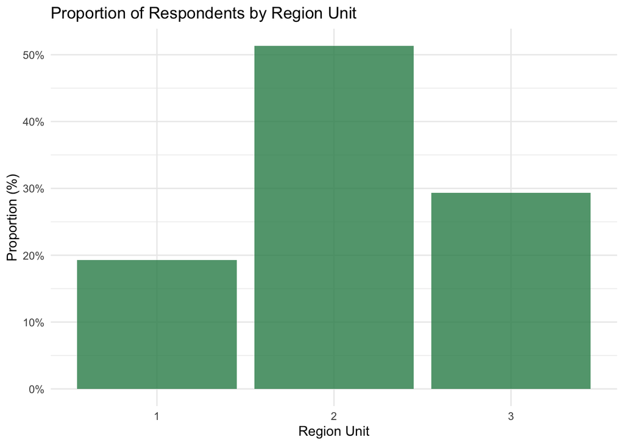

```r
# Bar plot showing proportion of respondents by region unit
ggplot(data2, aes(x = as.factor(regunit))) +
  geom_bar(aes(y = after_stat(count / sum(count))), fill = "seagreen", alpha = 0.8) +
  scale_y_continuous(labels = scales::percent_format()) +
  labs(title = "Proportion of Respondents by Region Unit",
       x = "Region Unit",
       y = "Proportion (%)") +
  theme_minimal()
```

**Interpretation** : Region Unit 2 has the highest number of respondents with 51.33%, followed by Region Unit 3 with 29.36% and lastly, Region Unit 1 has the lowest number of respondents with 19.31%. This indicates that most of the responses were from Region Unit 2

#### **(2) Correlation Table and Interpretation**

```r
## Correlation Matrix
corr_matrix <- data2 %>%
  select(att_homosex, gender_equal, instit_trust) %>%
  cor(use = "pairwise.complete.obs")

corr_matrix
```

```
##              att_homosex gender_equal instit_trust
## att_homosex    1.0000000    0.3437720    0.1683586
## gender_equal   0.3437720    1.0000000    0.1525787
## instit_trust   0.1683586    0.1525787    1.0000000
```

**Interpretation**: The correlation tables show that there is a moderately positive relationship between attitudes toward homosexuality and gender equality (r = .34), while both have weak positive correlations with institutional trust (r = .17 and r= .15) respectively. This indicate that people who support gender equality also tend to have more positive attitudes toward lesbian and gays. However, trust in institutions has only a small relation with these two attitudes.

#### **(3) Comparison of respondents’ attitudes towards gays and lesbians in regunit 2 and regunit 3 only**

```r
## Filtering the dataset to have only respondents from region units 2 and 3
data3 <- data2 %>% filter(regunit %in% c(2, 3))
head(data3) ## display the first six rows of new data 3
```

```
## # A tibble: 6 × 4
##   regunit att_homosex gender_equal instit_trust
##     <dbl>       <dbl>        <dbl>        <dbl>
## 1       2        3.67         6             7
## 2       2        5            5.25          3.4
## 3       2        5            5.75          5.6
## 4       2        3.67         5.25          5.2
## 5       2        4            6             6.4
## 6       2        4            5.25          5
```

```r
unique(data3$regunit) # Check the unique values in regunit
```

```
## [1] 2 3
```

#### **Visual comparison using boxplot**

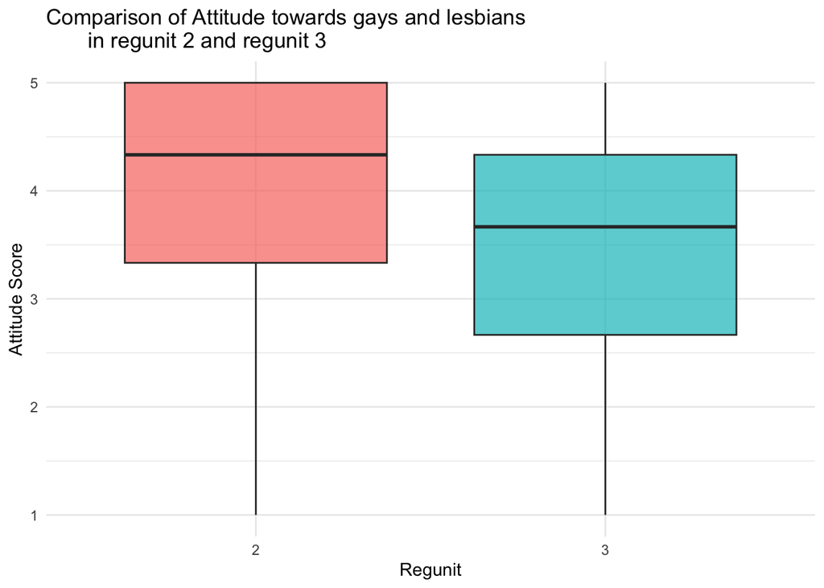

```r
ggplot(data3, aes(x = as_factor(regunit), y = att_homosex,
                  fill = as_factor(regunit))) +
  geom_boxplot(alpha = 0.7) +
  theme_minimal() +
  labs(title = "Comparison of Attitude towards gays and lesbians
       in regunit 2 and regunit 3 ",
       x = "Regunit", y = "Attitude Score")+
  theme(legend.position = "none")
```

#### **Statistical comparison using Independent sample t-test**

```r
t_test_result <- t.test(att_homosex ~ regunit, data = data3)
t_test_result
```

```
##
##  Welch Two Sample t-test
##
## data:  att_homosex by regunit
## t = 34.559, df = 19812, p-value < 2.2e-16
## alternative hypothesis: true difference in means between group 2 and group 3 is not equal to 0
## 95 percent confidence interval:
##  0.4399543 0.4928606
## sample estimates:
## mean in group 2 mean in group 3
##        3.959524        3.493116
```

**Interpretation**: An independent samples t-test was conducted to compare attitudes towards gays and lesbians in Region Unit 2 and Region Unit 3. Statistical comparison shows that there is a significant difference in attitudes toward gays and lesbians between respondents in Region Unit 2 and region unit 3 as p-value < .001. Respondents in Region Unit 2 (M = 3.96) have more positive attitudes than those in Region Unit 3 (M = 3.49)

## Principle component analysis

1. Perform principle component analysis on the df_regions data. Write the code in chunk ‘pca_chunk’ below.
2. Discuss and decide how many principal components you wish to retain.

Answer: Based on the results of the scree plot and the eigenvalues, we will be retaining 3 principal components. The Scree Plot shows that 3 PCs explain 82.2% of the variance, and then the plot elbow appears. Additionally, the eigenvalues have 3 PCs with values greater than 1, and then the rest are less than 1.

3. Discuss how you would like to label/interpret the retained principle components.

4. Do you prefer to have the observed variables standardized before running the pca? Why?

Answer: Yes, because the scales of the variables are not the same. By standardization, we ensure that all variables contribute equally to the analysis. If we don’t standardize, the variables with larger scales will have more effect on the PCA.

5. Do you have other suggestions to improve the analysis?

Answer: We ran the analysis with all variables and saw a cluster form with only the variable regunit, but we decided to rerun the analysis without that variable because it’s not meaningful in the context of the research question.

6. Explain in your own words why pca is an unsupervised machine learning alogorithm.

Answer: Because I did not specify anything that the machine should follow when looking for dimensionality reduction. The algorithm used to reduce dimensionality is only based on internal relationships between variables and had no input from me on how to predict that. Additionally, we do not have labelled data.

```r
 #install.packages('ggrepel')
 #install.packages('factoextra')
 #install.packages('corrplot')
library(factoextra)
 library(ggrepel)
library(corrplot)
 library(haven)

df_regions <- df_regions |>
  column_to_rownames("region") |>
  select(!regunit) #drop regunit from the pca

pca <- prcomp(df_regions, scale = TRUE, center = TRUE) #pca
head(pca$x)
```

```
##            PC1        PC2        PC3        PC4        PC5        PC6
## CY0  2.3063494  1.0722571  3.9604370  0.6154779 -0.3873906  0.2031763
## DE1 -1.8123995 -0.9330595  0.8597758  0.8937120  0.3739242  0.3981845
## DE2 -1.1986071 -1.0852406  1.0953884  1.4092048  0.8192543  0.3369576
## DE3 -2.1669986  0.6279344 -0.5702418  0.3823584 -0.7456531 -0.5350420
## DE4 -0.8068525  0.5254396 -0.8486101  0.5431785  0.5342144 -0.1648348
## DE6 -3.7986668 -1.2895546 -0.8729460 -0.3338702 -0.2663265 -0.1209395
##             PC7         PC8         PC9         PC10         PC11        PC12
## CY0 -0.11443121 -0.15789512 -0.33332068  0.005417379  0.082287993 -0.08141003
## DE1 -0.10949483  0.14305513 -0.08533835  0.043170658  0.144813186  0.06649147
## DE2 -0.44993522  0.11288642 -0.08001932  0.143040711 -0.020683665  0.08059329
## DE3  0.16571056 -0.09349506 -0.64093791 -0.238645542  0.267964260 -0.11204257
## DE4 -0.08018978  0.21291474 -0.30891545  0.009352973  0.209447044 -0.08164793
## DE6 -0.03851292 -0.13824303 -0.18550563  0.169566995 -0.007167216  0.16914470
##            PC13
## CY0  0.11141027
## DE1  0.05094956
## DE2  0.00919465
## DE3 -0.17039238
## DE4 -0.21162278
## DE6  0.11096304
```

```r
  pca$rotation #rotation
```

```
##                  PC1         PC2         PC3         PC4          PC5
## n_resp   -0.03014859 -0.04237972  0.92307994  0.35130837  0.071272602
## eqmgmbg  -0.28332698  0.34741899  0.10147510 -0.17327963 -0.082338733
## eqpaybg  -0.27354358  0.32979947  0.01671872 -0.18066943  0.032474662
## eqpolbg  -0.29400969  0.30160745  0.12299101 -0.21659483 -0.156288895
## eqwrkbg  -0.19160426  0.39969796  0.14130426 -0.29193664  0.088665020
## freehms  -0.32915403  0.07587415 -0.15345709  0.47216947 -0.028066224
## hmsacld  -0.33665234  0.07943900 -0.18250113  0.34643417 -0.005495085
## hmsfmlsh -0.32941006  0.08964243 -0.17996997  0.43898750  0.055884833
## trstlgl  -0.27132741 -0.34441593  0.02945535 -0.00928295  0.376492402
## trstplc  -0.27137067 -0.21968114 -0.02586233 -0.26198923  0.706286099
## trstplt  -0.27661104 -0.34934205  0.02945528 -0.12258602 -0.368560997
## trstprl  -0.30608875 -0.28780659  0.09936830 -0.20130375 -0.185053154
## trstprt  -0.27052568 -0.35518017  0.02701737 -0.14774678 -0.374417891
##                   PC6          PC7         PC8          PC9        PC10
## n_resp    0.022000514 -0.079972434  0.06864607  0.065273941  0.01971042
## eqmgmbg   0.290073678  0.262709239  0.13663175  0.048037803 -0.21706205
## eqpaybg   0.315612853 -0.748197220 -0.10842685 -0.152597708 -0.08686823
## eqpolbg   0.309279017  0.470897184 -0.08832463  0.031235965  0.10336364
## eqwrkbg  -0.822040318  0.021129898 -0.04628488 -0.001122146 -0.06508876
## freehms  -0.020712849  0.233296449 -0.26856756  0.006460765  0.26362918
## hmsacld  -0.096959185 -0.055313486  0.77620279 -0.270216662  0.05518972
## hmsfmlsh -0.087600711 -0.176716638 -0.38213535  0.341686354 -0.14363794
## trstlgl   0.007249468  0.192550506 -0.20663702 -0.521491541 -0.55028741
## trstplc   0.094921988  0.004064652  0.17578345  0.432374694  0.28039690
## trstplt  -0.104827937 -0.058606179  0.06469377  0.301233809 -0.12209609
## trstprl  -0.071412784 -0.094181426 -0.20836514 -0.419484570  0.60972220
## trstprt  -0.041262083 -0.066977049  0.11433656  0.231840270 -0.26218982
##                  PC11        PC12          PC13
## n_resp   -0.004008937  0.02153450 -0.0004374993
## eqmgmbg  -0.011410317 -0.67426487 -0.2755162091
## eqpaybg  -0.231223497  0.13487385  0.0936819722
## eqpolbg   0.227477602  0.53317191  0.2514914282
## eqwrkbg  -0.075389622  0.04495209 -0.0138864133
## freehms  -0.662119249  0.01483084 -0.0589169416
## hmsacld   0.149745975  0.09170949  0.0717793989
## hmsfmlsh  0.571126285 -0.06438084 -0.0508850890
## trstlgl  -0.014413936  0.03508744  0.0949900847
## trstplc  -0.054496592  0.01242674 -0.0364659079
## trstplt  -0.135391803 -0.24744505  0.6677545883
## trstprl   0.260837878 -0.21141907 -0.1448663896
## trstprt  -0.111372365  0.34688776 -0.6028477620
```

We **standardized the observed variables** before running the PCA because they were measured on **different scales**.  
Standardization ensures that each variable contributes **equally** to the analysis.  
Without standardization, variables with larger numeric ranges would dominate the principal components, biasing the results.

Additionally, during initial runs, we observed that the variable `regunit` formed a separate cluster unrelated to the main constructs of interest. Since this variable does not meaningfully contribute to the conceptual focus of the study, it was **excluded** from the final PCA.

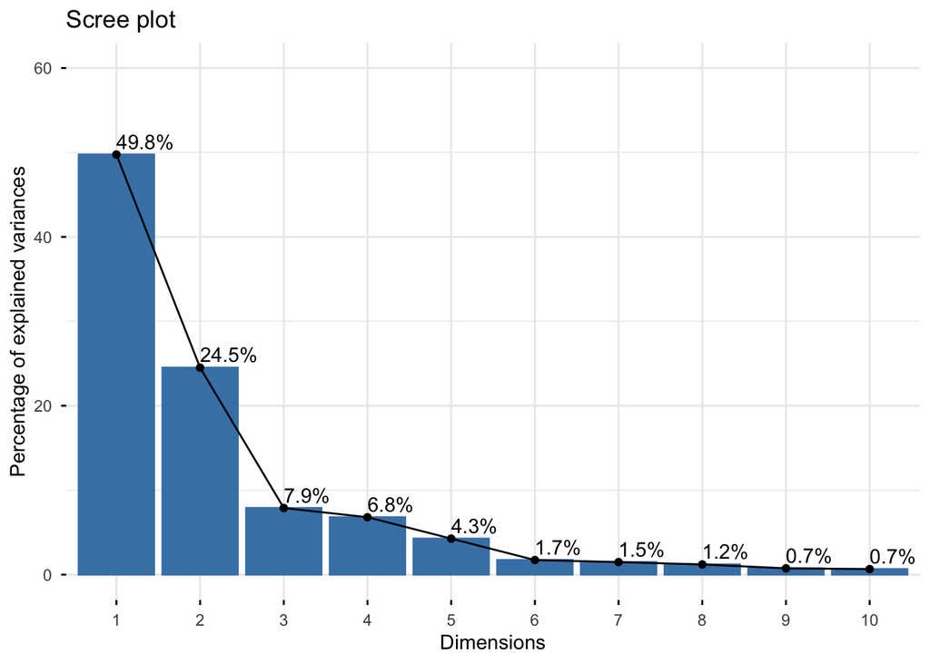

```r
  fviz_eig(pca, addlabels = TRUE, ylim = c(0, 60)) #scree plot
```

```r
  eig.val<- get_eig(pca) #eigenvalues
  eig.val
```

```
##        eigenvalue variance.percent cumulative.variance.percent
## Dim.1  6.46862828       49.7586790                    49.75868
## Dim.2  3.18648387       24.5114144                    74.27009
## Dim.3  1.02563849        7.8895269                    82.15962
## Dim.4  0.88411854        6.8009118                    88.96053
## Dim.5  0.55436757        4.2643659                    93.22490
## Dim.6  0.22495312        1.7304086                    94.95531
## Dim.7  0.19282246        1.4832497                    96.43856
## Dim.8  0.15679149        1.2060884                    97.64464
## Dim.9  0.09701284        0.7462526                    98.39090
## Dim.10 0.08509570        0.6545823                    99.04548
## Dim.11 0.07123668        0.5479745                    99.59345
## Dim.12 0.03127410        0.2405700                    99.83402
## Dim.13 0.02157685        0.1659758                   100.00000
```

Based on the scree plot and eigenvalues, **three principal components (PCs)** were retained.

The first three components together explain **82.2% of the total variance**, after which the scree plot shows a clear **elbow**.

Additionally, the first three PCs have **eigenvalues greater than 1**, while the remaining components fall below 1.

Therefore, retaining 3 PCs captures most of the variance in the data while maintaining interpretability.

```r
n_pc<-3 #or any other number of PC's you want to retain
# prcomp.res is the outcome of prcomp-function
df_regions |>
  bind_cols(predict(pca, newdata = df_regions)[,1:n_pc])->
  df_regions_pca
```

Based on the scree plot and eigenvalues, we append retained PC scores as new columns to the original dataset.

```r
 loadings <- pca$rotation %>% as.data.frame() #factor loadings
  apply(loadings, 2, function(x) sort(x, decreasing = TRUE))
```

```
##               PC1         PC2         PC3         PC4          PC5          PC6
##  [1,] -0.03014859  0.39969796  0.92307994  0.47216947  0.706286099  0.315612853
##  [2,] -0.19160426  0.34741899  0.14130426  0.43898750  0.376492402  0.309279017
##  [3,] -0.27052568  0.32979947  0.12299101  0.35130837  0.088665020  0.290073678
##  [4,] -0.27132741  0.30160745  0.10147510  0.34643417  0.071272602  0.094921988
##  [5,] -0.27137067  0.08964243  0.09936830 -0.00928295  0.055884833  0.022000514
##  [6,] -0.27354358  0.07943900  0.02945535 -0.12258602  0.032474662  0.007249468
##  [7,] -0.27661104  0.07587415  0.02945528 -0.14774678 -0.005495085 -0.020712849
##  [8,] -0.28332698 -0.04237972  0.02701737 -0.17327963 -0.028066224 -0.041262083
##  [9,] -0.29400969 -0.21968114  0.01671872 -0.18066943 -0.082338733 -0.071412784
## [10,] -0.30608875 -0.28780659 -0.02586233 -0.20130375 -0.156288895 -0.087600711
## [11,] -0.32915403 -0.34441593 -0.15345709 -0.21659483 -0.185053154 -0.096959185
## [12,] -0.32941006 -0.34934205 -0.17996997 -0.26198923 -0.368560997 -0.104827937
## [13,] -0.33665234 -0.35518017 -0.18250113 -0.29193664 -0.374417891 -0.822040318
##                PC7         PC8          PC9        PC10         PC11
```

[output cut: 27 more lines]

```r
round(loadings, 3) #round loadings to 3
```

```
##             PC1    PC2    PC3    PC4    PC5    PC6    PC7    PC8    PC9   PC10
## n_resp   -0.030 -0.042  0.923  0.351  0.071  0.022 -0.080  0.069  0.065  0.020
## eqmgmbg  -0.283  0.347  0.101 -0.173 -0.082  0.290  0.263  0.137  0.048 -0.217
## eqpaybg  -0.274  0.330  0.017 -0.181  0.032  0.316 -0.748 -0.108 -0.153 -0.087
## eqpolbg  -0.294  0.302  0.123 -0.217 -0.156  0.309  0.471 -0.088  0.031  0.103
## eqwrkbg  -0.192  0.400  0.141 -0.292  0.089 -0.822  0.021 -0.046 -0.001 -0.065
## freehms  -0.329  0.076 -0.153  0.472 -0.028 -0.021  0.233 -0.269  0.006  0.264
## hmsacld  -0.337  0.079 -0.183  0.346 -0.005 -0.097 -0.055  0.776 -0.270  0.055
## hmsfmlsh -0.329  0.090 -0.180  0.439  0.056 -0.088 -0.177 -0.382  0.342 -0.144
## trstlgl  -0.271 -0.344  0.029 -0.009  0.376  0.007  0.193 -0.207 -0.521 -0.550
## trstplc  -0.271 -0.220 -0.026 -0.262  0.706  0.095  0.004  0.176  0.432  0.280
## trstplt  -0.277 -0.349  0.029 -0.123 -0.369 -0.105 -0.059  0.065  0.301 -0.122
## trstprl  -0.306 -0.288  0.099 -0.201 -0.185 -0.071 -0.094 -0.208 -0.419  0.610
## trstprt  -0.271 -0.355  0.027 -0.148 -0.374 -0.041 -0.067  0.114  0.232 -0.262
##            PC11   PC12   PC13
## n_resp   -0.004  0.022  0.000
## eqmgmbg  -0.011 -0.674 -0.276
## eqpaybg  -0.231  0.135  0.094
## eqpolbg   0.227  0.533  0.251
## eqwrkbg  -0.075  0.045 -0.014
## freehms  -0.662  0.015 -0.059
## hmsacld   0.150  0.092  0.072
## hmsfmlsh  0.571 -0.064 -0.051
## trstlgl  -0.014  0.035  0.095
## trstplc  -0.054  0.012 -0.036
## trstplt  -0.135 -0.247  0.668
## trstprl   0.261 -0.211 -0.145
## trstprt  -0.111  0.347 -0.603
```

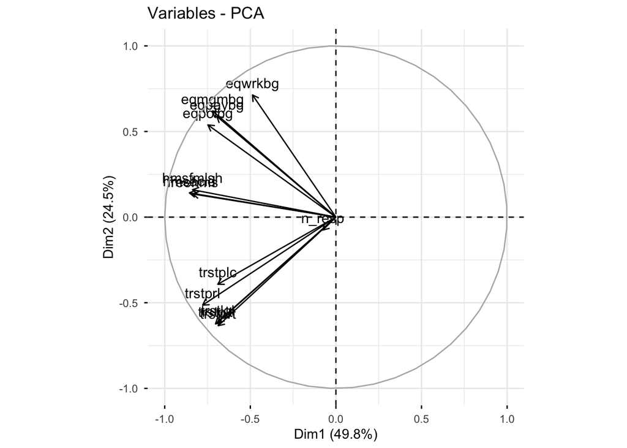

```r
fviz_pca_var(pca) #biplot
```

## Cluster analysis

1. Run k-means & hierarchical cluster analysis. Write the code in chunk ‘cluster_chunk’.
2. Would you prefer to run both analyses on the retained PC’s or on the original set of observed variables? Argue.

**Answer:**

In this case, I don’t see the big incentive of running the cluster algorithms on PCs, simply because our data doesn’t appear to be high-dimensional (264 regions vs 12 features). I would prefer to run both analyses only on PCs if they wouldn’t converge on the original variables, or there would be clear sings that our data has multicolleniarity issues, noise, etc.

A set of PCs that we choose doesn’t retain all the variance of the original data (and if it does, then it is equivalent to running cluster analyses on observed variables rotated) — so it would be to an extent a simplification. Not only that, each PC has different variance (by definition they are sorted from the highest eigenvalue to the lowest) — cluster algorithms will be giving more influence to higher variance PCs as they (most commonly) use Euclidean distances or a modified version of it, which are sensitive.

Nevertheless, if our set of principal components explains more than 80% variance of the original data, and we expect that most of our cluster separation lies in the higher order components, I don’t see why it would be wrong or unacceptable to run cluster analyses on PCs — it will still be meaningful.

3. Would you advice to standardize the observed variables before running the cluster algorithms?

**Answer:**

Yes, absolutely.

In case of K-Means, we are dealing with Euclidean distances between observations and their cluster centriods on each iteration of the algorithm — so in case of different variable scales, the result accuracy would benefit a lot from the standardization, unless we want to end up with variables having different weight and influence in the clustering. But even then, it would still be reasonable to standardize and manually re-scale them.

In case of the hierarchical clustering, most of the linkage approaches also employ Euclidean distances (or other distance measures, but almost all of them are still sensitive to variables being scaled differently) — so the same logic applies, distances are mathematically scale-dependent.

**In this case, our variables have different scales (0-10, 0-6, 1-5), so I will standardize them.**

4. Would you advice to standardize the PC’s before running the cluster algorithms?

**Answer:**

Generally, I would say it depends. But it’s more often “no” than “yes”.

PCA returns the PCs that are, in principle, sorted from the highest eigenvalue to the lowest, meaning that the variance of the first discovered principal component is bound to be bigger than variance of the last one. Thus, depending on how many PCs we decide to retrieve for our dataset, we may choose to standardize the PCs or not to.

In most cases we don’t really need to standardize PCs — yes, the variance, and hence the influence, of each component on the clustering may vary, but if we reduce the dataset to a moderate number of PCs, it would be a solid decision. Not standardizing is just keeping the variance weights from the PCA.

However, if we have reasons to believe that our structure of potential clusters lies in the lower-variance PCs, and we reduce our dataset to a relatively high number of PCs during PCA (let’s say 7, for instance) — in this case, we might want to actually standardize our PCs and force their variance to be equal. This way, PCs with low eigenvalues won’t be overpowered and will still have an influence on the clustering. This is more for when our data is noisy or something else is wrong with it.

5. How many clusters of regions do you wish to retain? Argue.

**Answer:**

For both K-means and hierarchical (Ward) I ultimately decided to retain 3 clusters. In fact, performance-wise, the 2 clusters solutions would be the best ones in both of those algorithms, however for the sake of not losing meaningful separations and better interpretability, more clusters were retained. 3-cluster solution was slightly better than 4-cluster solution for the K-means, and for the Ward they were almost equivalent (preference given to 3-cluster solution for better comparability with the K-means result).

6. Interpret the clusters you retained. Do you have any suggestions for improving the result (e.g. omitting certain features or regions)?

**Answer:**

**K-means** (please kindly find the full interpretation below):

- **First cluster** (131 region) — high tolerance, pro-equality, high trust;
- **Second cluster** (83 regions) — low tolerance, moderate on equality, very low trust;
- **Third cluster** (50 regions) — very low tolerance, against equality, low trust.

**Hierarchical clustering (Ward)** (please kindly find the full interpretation below):

- **First cluster** (112 regions) — very low tolerance, against equality, low trust;
- **Second cluster** (85 regions) — high tolerance, pro-equality (work parity ~ average), very high trust;
- **Third cluster** (67 regions) — high tolerance, pro-equality, low trust.

I would suggest removing **ES64, LT021, SK021** regions as in both cases they were the outliers that hindered clusters’ tightness.

### Data preparation for cluster analysis

```r
df_regions <- df_regions_forlater
# Selecting the feature variables (only available ones, ppltrst, pplfair and pplhlp are not available in the "regions" dataset)

features <- c("freehms","hmsacld","hmsfmlsh", "eqmgmbg","eqpolbg","eqwrkbg","eqpaybg", "trstprl","trstlgl","trstplc","trstplt","trstprt")

# There are no NAs left after the first part so we can proceed comfortably
colSums(is.na(df_regions[features]))
```

```
##  freehms  hmsacld hmsfmlsh  eqmgmbg  eqpolbg  eqwrkbg  eqpaybg  trstprl
##        0        0        0        0        0        0        0        0
##  trstlgl  trstplc  trstplt  trstprt
##        0        0        0        0
```

```r
# It is very important that we standardize the variables — I am using Z-scores
df_regions <- df_regions |> mutate(across(all_of(features), ~ c(scale(.))))

head(df_regions)
```

```
## # A tibble: 6 × 15
##   regunit region n_resp eqmgmbg eqpaybg eqpolbg eqwrkbg freehms hmsacld hmsfmlsh
##     <dbl> <chr>   <int>   <dbl>   <dbl>   <dbl>   <dbl>   <dbl>   <dbl>    <dbl>
## 1       1 CY0       685  0.0596  -0.137  0.0760   0.159  -1.04   -1.23    -1.13
## 2       1 DE1       332  0.123    0.235  0.247   -0.480   0.646   0.822    0.742
## 3       1 DE2       396 -0.334    0.207 -0.338   -0.684   0.696   0.715    0.706
## 4       1 DE3        82  0.785    0.440  0.625    0.849   0.889   1.17     1.04
## 5       1 DE4        72  0.241    0.251 -0.0752   0.241   0.478   0.932    0.710
## 6       1 DE6        39  0.365    0.705  0.819    0.264   1.21    1.21     1.09
## # ℹ 5 more variables: trstlgl <dbl>, trstplc <dbl>, trstplt <dbl>,
## #   trstprl <dbl>, trstprt <dbl>
```

```r
dim(df_regions)
```

```
## [1] 264  15
```

### K-means

Let’s start with finding the optimal number of clusters.

One way to do it is by looking at the Elbow plot:

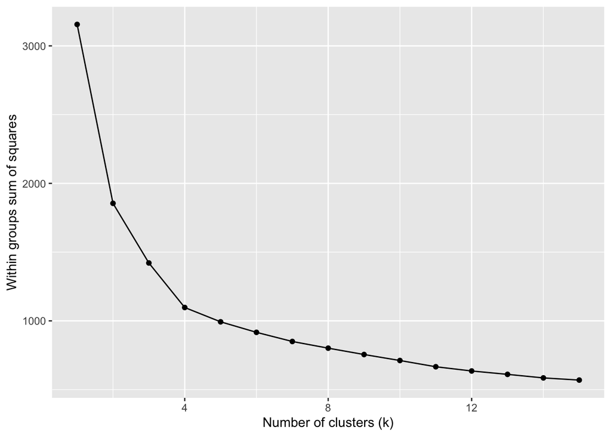

```r
d_in <- df_regions %>%
  select(region, all_of(features)) %>%
  column_to_rownames("region")

wss <- list()
km_store <- list()

# Let's try finding SS for 1-15 cluster solutions (30 nstarts each)
for (i in 1:15) {
  set.seed(1000 + i)
  km.out <- kmeans(d_in, centers = i, nstart = 30, iter.max = 100)
  wss[[i]] <- tibble(k = i, ss = km.out$tot.withinss)
  km_store[[as.character(i)]] <- km.out
}

wss <- bind_rows(wss)

# Elbow plot
ggplot(wss, aes(x = k, y = ss)) +
  geom_line() + geom_point() +
  xlab("Number of clusters (k)") +
  ylab("Within groups sum of squares")
```

**Interpretation**: I would say that k=2, k=3, k=4 could all be considered viable choices (it is a bit ambiguous). However, let’s try to avoid k=2, as even though it might perform better on separation in cluster algorithms, we risk overlooking meaningfully distinct clusters, which can make interpretation harder.

Let’s do a silhouette (example from scikit documentation used as a reference) plot to make a final decision:

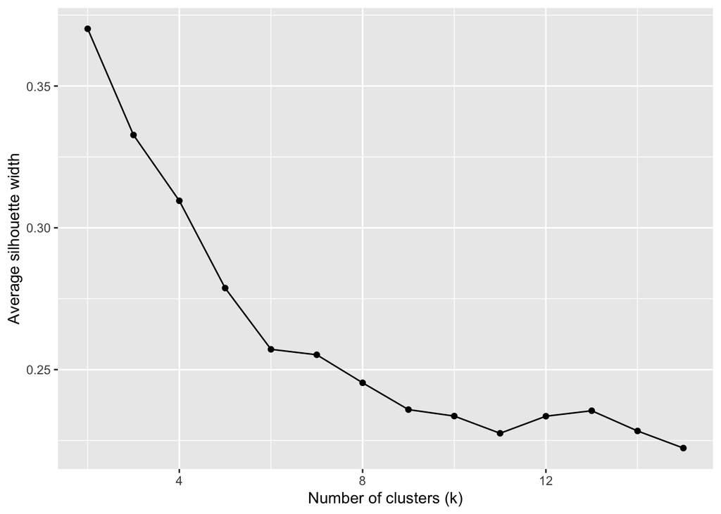

```r
# Calculating silhouette for k in range(2, 16)
sil_tbl <- lapply(2:15, function(k){
  set.seed(1000 + k)
  km <- kmeans(d_in, centers = k, nstart = 25, iter.max = 100)
  sil <- silhouette(km$cluster, dist(d_in))
  tibble(k = k, asw = mean(sil[, 3]))
}) %>% bind_rows()

# Average silhouette width
ggplot(sil_tbl, aes(k, asw)) +
  geom_line() + geom_point() +
  labs(x = "Number of clusters (k)", y = "Average silhouette width")
```

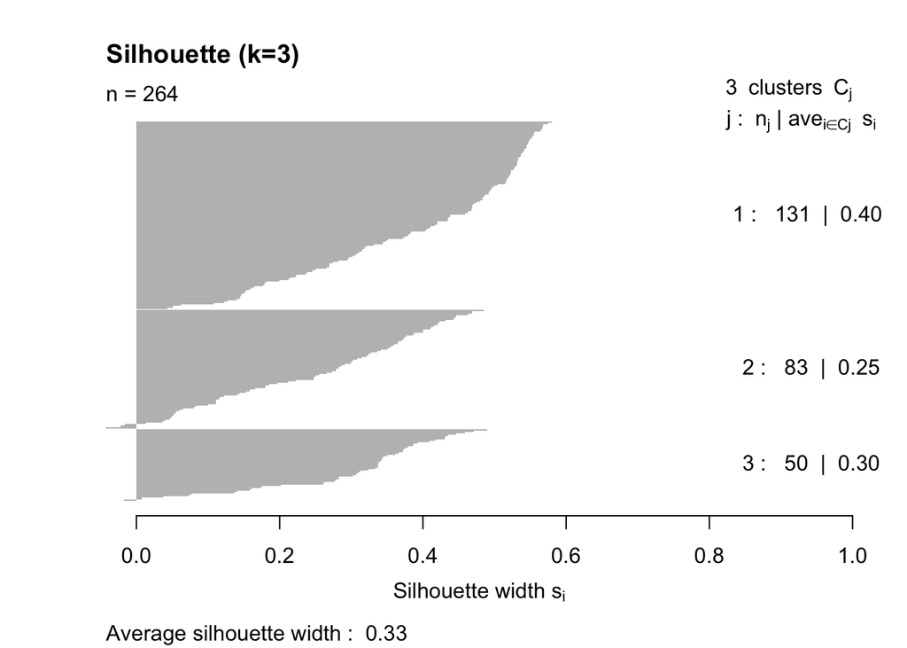

```r
# Silhouette visualisation for k=3
set.seed(123)
clusterer3 <- kmeans(d_in, centers = 3, nstart = 50)
sil3 <- silhouette(clusterer3$cluster, dist(d_in))
plot(sil3, border = NA, main = paste("Silhouette (k=3)"))
```

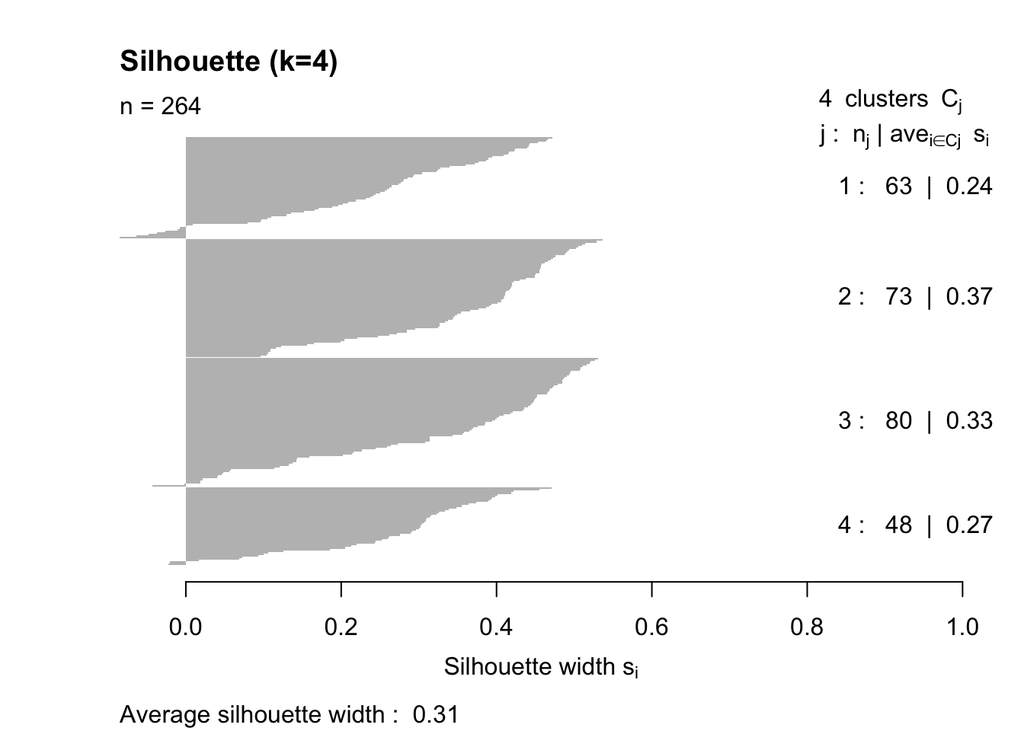

```r
# Silhouette visualisation for k=4
clusterer4 <- kmeans(d_in, centers = 4, nstart = 50)
sil4 <- silhouette(clusterer4$cluster, dist(d_in))
plot(sil4, border = NA, main = paste("Silhouette (k=4)"))
```

**Intepretation**: both clusters have “okay” overall ASW (so we can avoid k=2), but k=4 is borderline (0,31). Also, 2 of the k=4 clusters have very low ASWs (0,24 and 0,27), and with k=3 only one cluster has low ASW (0,25). Considering that, let’s proceed with 3 clusters (still keeping 4 clusters option in mind — it only looks slightly worse, not significantly).

```r
# Let's run the K-means algorithm:
set.seed(123)
km.res <- kmeans(d_in, centers = 3, nstart = 50, iter.max = 100)
print(km.res)
```

```
## K-means clustering with 3 clusters of sizes 131, 83, 50
##
## Cluster means:
##      freehms    hmsacld   hmsfmlsh    eqmgmbg    eqpolbg    eqwrkbg    eqpaybg
## 1  0.7284857  0.7523381  0.7198144  0.5318754  0.5371321  0.2982950  0.5240448
## 2 -0.4729889 -0.5029784 -0.4165644  0.1322147  0.1004638  0.3682343  0.2106961
## 3 -1.1234710 -1.1361818 -1.1944170 -1.6129899 -1.5740560 -1.3928017 -1.7227531
##      trstprl    trstlgl    trstplc    trstplt    trstprt
## 1  0.7008373  0.6618813  0.6396508  0.6577735  0.6376859
## 2 -0.8271232 -0.9730696 -0.8063084 -0.9272276 -0.8808654
## 3 -0.4631691 -0.1188333 -0.3374131 -0.1841687 -0.2085005
##
## Clustering vector:
##   CY0   DE1   DE2   DE3   DE4   DE6   DE7   DE8   DE9   DEA   DEB   DEC   DED
##     2     1     1     1     1     1     1     1     1     1     1     1     1
##   DEE   DEF   DEG   ITC   ITF   ITG   ITH   ITI   UKC   UKD   UKE   UKF   UKG
##     2     1     1     2     2     2     1     1     2     2     2     2     2
##   UKH   UKI   UKJ   UKK   UKL   UKM   UKN  AT11  AT12  AT13  AT21  AT22  AT31
##     1     1     1     2     2     2     2     1     1     1     3     1     1
##  AT32  AT33  AT34  BE10  BE21  BE22  BE23  BE24  BE25  BE31  BE32  BE33  BE34
##     1     1     3     1     1     1     1     1     1     1     2     1     1
##  BE35  CH01  CH02  CH03  CH04  CH05  CH06  CH07  EL30  EL41  EL42  EL43  EL51
##     1     1     1     1     1     1     1     1     2     3     3     3     2
##  EL52  EL53  EL54  EL61  EL62  EL63  EL64  EL65  ES11  ES12  ES13  ES21  ES22
##     3     3     3     2     3     3     3     3     1     2     1     1     2
##  ES23  ES24  ES30  ES41  ES42  ES43  ES51  ES52  ES53  ES61  ES62  ES64  ES70
##     2     1     1     1     1     2     2     1     1     1     1     1     1
##  FR10  FRB0  FRC1  FRC2  FRD1  FRD2  FRE1  FRE2  FRF1  FRF2  FRF3  FRG0  FRH0
##     1     1     2     1     1     2     1     1     1     2     1     1     1
##  FRI1  FRI2  FRI3  FRJ1  FRJ2  FRK1  FRK2  FRL0  NL11  NL12  NL13  NL21  NL22
##     1     1     1     1     1     1     1     1     1     1     1     1     1
##  NL23  NL31  NL32  NL33  NL34  NL41  NL42  NO02  NO06  NO07  NO08  NO09  NO0A
##     1     1     1     1     1     1     1     1     1     1     1     1     1
##  PL21  PL22  PL41  PL42  PL43  PL51  PL52  PL61  PL62  PL63  PL71  PL72  PL81
##     2     2     2     2     2     2     2     2     2     2     2     2     2
##  PL82  PL84  PL91  PL92  PT11  PT15  PT16  PT17  PT18  RS11  RS12  RS21  RS22
##     2     3     2     2     2     1     2     1     2     2     2     2     2
##  SE11  SE12  SE21  SE22  SE23  SE31  SE32  SE33 FI193 FI194 FI195 FI196 FI197
##     1     1     1     1     1     1     1     1     1     1     1     1     1
## FI1B1 FI1C1 FI1C2 FI1C3 FI1C4 FI1C5 FI1D1 FI1D2 FI1D3 FI1D5 FI1D7 FI1D8 FI1D9
```

[output cut: 9 more lines]

```
## LT011 LT021 LT022 LT023 LT024 LT025 LT026 LT027 LT028 LT029 SI031 SI032 SI033
##     3     3     3     3     3     3     3     3     3     3     2     2     2
## SI034 SI035 SI036 SI037 SI038 SI041 SI042 SI043 SI044 SK010 SK021 SK022 SK023
##     2     2     3     2     2     2     2     2     2     3     3     3     3
## SK031 SK032 SK041 SK042
##     3     3     3     3
##
## Within cluster sum of squares by cluster:
## [1] 612.0445 481.2956 327.7182
##  (between_SS / total_SS =  55.0 %)
##
## Available components:
##
## [1] "cluster"      "centers"      "totss"        "withinss"     "tot.withinss"
## [6] "betweenss"    "size"         "iter"         "ifault"
```

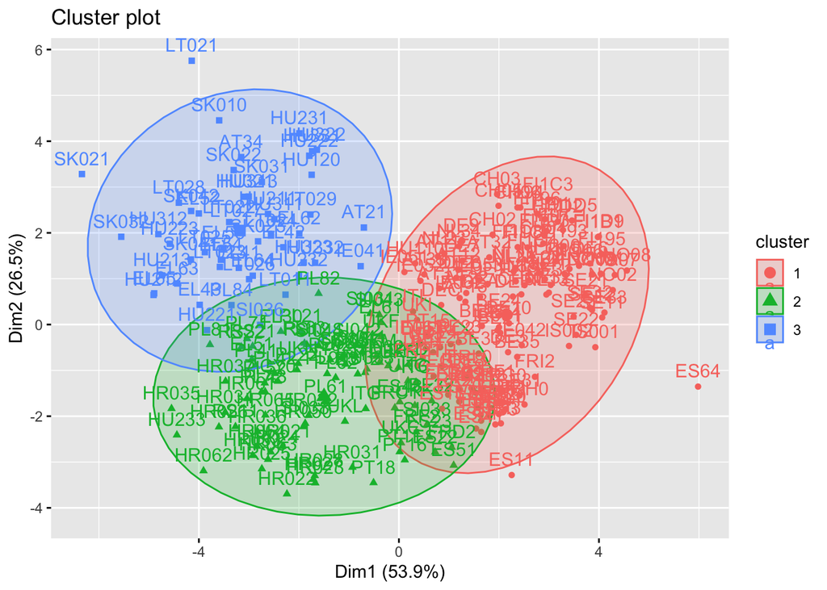

```r
# Plot (does PCA for 2-dimensional visualisation)
fviz_cluster(km.res, data = d_in, ellipse.type = "norm")
```

```r
# Let's attach cluster labels back to region table:
cluster_map <- tibble(region = rownames(d_in), cl_kmeans = km.res$cluster)
df_regions_cl <- df_regions %>%
  left_join(cluster_map, by = "region")

# Cluster means of variables
profile <- df_regions_cl %>%
  group_by(cl_kmeans) %>%
  summarise(across(all_of(features), mean), .groups = "drop")
profile  %>%
  kable("html", caption = "Cluster means of variables") %>%
  kable_styling(bootstrap_options = "striped", full_width = F) %>%
  scroll_box(width = "100%", height = "auto")
```

Cluster means of variables

| cl_kmeans | freehms | hmsacld | hmsfmlsh | eqmgmbg | eqpolbg | eqwrkbg | eqpaybg | trstprl | trstlgl | trstplc | trstplt | trstprt |
| --- | --- | --- | --- | --- | --- | --- | --- | --- | --- | --- | --- | --- |
| 1 | 0.7284857 | 0.7523381 | 0.7198144 | 0.5318754 | 0.5371321 | 0.2982950 | 0.5240448 | 0.7008373 | 0.6618813 | 0.6396508 | 0.6577735 | 0.6376859 |
| 2 | -0.4729889 | -0.5029784 | -0.4165644 | 0.1322147 | 0.1004638 | 0.3682343 | 0.2106961 | -0.8271232 | -0.9730696 | -0.8063084 | -0.9272276 | -0.8808654 |
| 3 | -1.1234710 | -1.1361818 | -1.1944170 | -1.6129899 | -1.5740560 | -1.3928017 | -1.7227531 | -0.4631691 | -0.1188333 | -0.3374131 | -0.1841687 | -0.2085005 |

```r
# Distances between cluster centroids (to see which clusters are the farthest apart)
as.matrix(dist(km.res$centers))  %>%
  kable("html", caption = "Distances between cluster centroids") %>%
  kable_styling(bootstrap_options = "striped", full_width = F)
```

Distances between cluster centroids

| 1 | 2 | 3 |
| --- | --- | --- |
| 0.000000 | 4.084233 | 5.654200 |
| 4.084233 | 0.000000 | 4.025495 |
| 5.654200 | 4.025495 | 0.000000 |

Interpretation:

55% of the total variation is explained by the cluster centroids’ differences, which means that we have a moderate separation, and the residual variance (45%) is somewhere within clusters.

From the plot, we can see some outliers: ES64, LT021, SK021.

In the **first cluster (131 region, red on the plot)**, we can see that:

- ‘freehms’, ‘hmsacld’, ‘hmsfmlsh’ (LGBT tolerance variables) are ≈0,72 to ≈0,75 above average — considerably higher;
- ‘eqmgmbg’, ‘eqpolbg’, ‘eqwrkbg’, ‘eqpaybg’ (gender equality support variables) are ≈0,30 to +0,54 above average — moderately higher;
- ‘trstprl’, ‘trstlgl’, ‘trstplc’, ‘trstplt’, ‘trstprt’ (institutional trust variables) are ≈0,64 to ≈0,7 above average — considerably higher.

Conclusion: we can label this cluster as “**High tolerance, pro-equality, high trust**”.

In the **second cluster (83 regions, green on the plot)**, we can see that:

- ‘freehms’, ‘hmsacld’, ‘hmsfmlsh’ (LGBT tolerance variables) are ≈0,42 to ≈0,5 below average — moderately lower;
- ‘eqmgmbg’, ‘eqpolbg’, ‘eqwrkbg’, ‘eqpaybg’ (gender equality support variables) are ≈0,1 to +0,37 above average — slightly higher;
- ‘trstprl’, ‘trstlgl’, ‘trstplc’, ‘trstplt’, ‘trstprt’ (institutional trust variables) are ≈0,81 to ≈0,97 below average — drastically lower.

Conclusion: we can label this cluster as “**Low tolerance, moderate on equality, very low trust**”.

In the **third cluster (50 regions, blue on the plot)**, we can see that:

Conclusion: we can label this cluster as “**Very low tolerance, against equality, low trust**”.

The first and the third cluster are the farthest from each other (5.654200), and the second claster is equally distant from both of them (4.025495 and 4.084233) in euclidean space.

### Hierarchical clustering

Let’s now proceed with the hierarchical clustering. Ward’s linkage (and, correspondingly, Euclidean distances as Ward doesn’t digest anything else) were chosen so that we would have a similar logic for clustering as K-means (tries to minimize within-cluster SSE increase with each iteration), but with a hierachical approach (bottom-up and greedy).

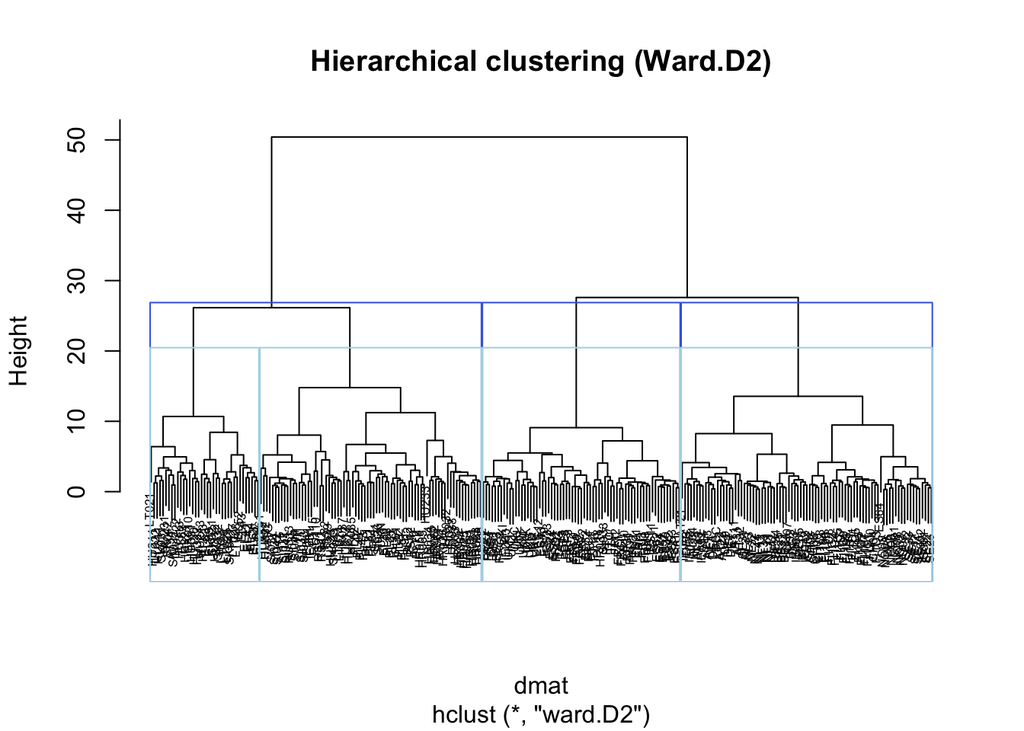

```r
# Let's run hierarchical clustering and look at the dendrogram:
dmat   <- dist(d_in, method = "euclidean")
hc_full <- hclust(dmat, method = "ward.D2")

# Dendrogram (with k=3 and k=4 lines)
plot(hc_full, cex = 0.5, main = "Hierarchical clustering (Ward.D2)")
rect.hclust(hc_full, k = 3, border = "royalblue")
rect.hclust(hc_full, k = 4, border = "lightblue")
```

**Interpretation**: as we can see from the dendrogram, the best possible solution would actually be the 2 clusters, however, for the reasons mentioned in the “Data preparation for cluster analyses” section, let’s try to avoid it. Between k=3 and k=4 it is a bit unclear which case would be better, so let’s check both of their silhouettes in the further steps.

```r
# 3 clusters silhouette
cl_hier3 <- cutree(hc_full, k = 3)
table(cl_hier3) %>%
  kable("html", caption = "3 clusters silhouette") %>%
  kable_styling(bootstrap_options = "striped", full_width = F)
```

3 clusters silhouette

| cl_hier3 | Freq |
| --- | --- |
| 1 | 112 |
| 2 | 85 |
| 3 | 67 |

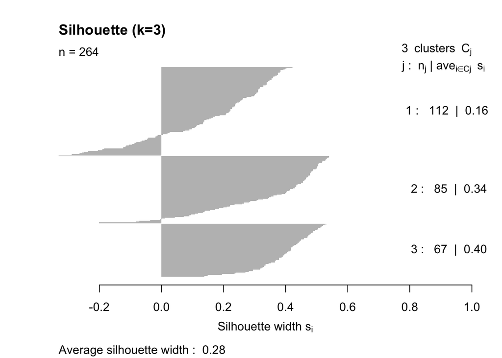

```r
sil_h <- silhouette(cl_hier3, dmat)
plot(sil_h, border = NA, main = "Silhouette (k=3)")
```

```r
# 4 clusters silhouette
cl_hier4 <- cutree(hc_full, k = 4)
table(cl_hier4) %>%
  kable("html", caption = "4 clusters silhouette") %>%
  kable_styling(bootstrap_options = "striped", full_width = F)  %>%
  scroll_box(width = "100%", height = "auto")
```

4 clusters silhouette

| cl_hier4 | Freq |
| --- | --- |
| 1 | 75 |
| 2 | 85 |
| 3 | 67 |
| 4 | 37 |

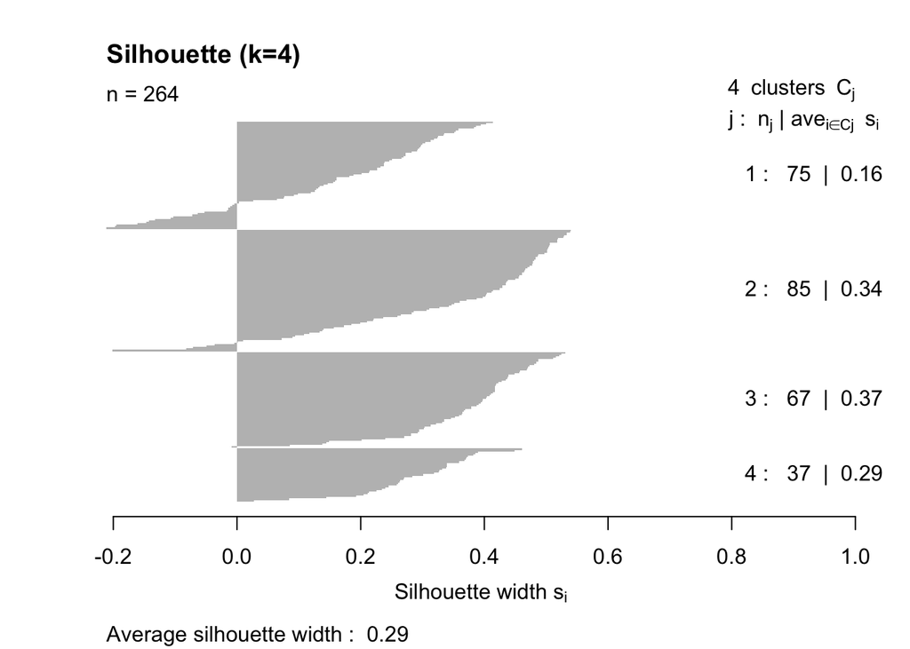

```r
sil_h <- silhouette(cl_hier4, dmat)
plot(sil_h, border = NA, main = "Silhouette (k=4)")
```

**Interpretation**: ASWs for both k=3 and k=4 are almost equal (the 0,01 difference could be considered marginal). In both of those solutions there is a weakest cluster with 0,16 width. Thus both solutions are nearly equivalent in terms of performance.

Let’s give a preference to k=3 solution for the sake of easier comparability with the k-means result:

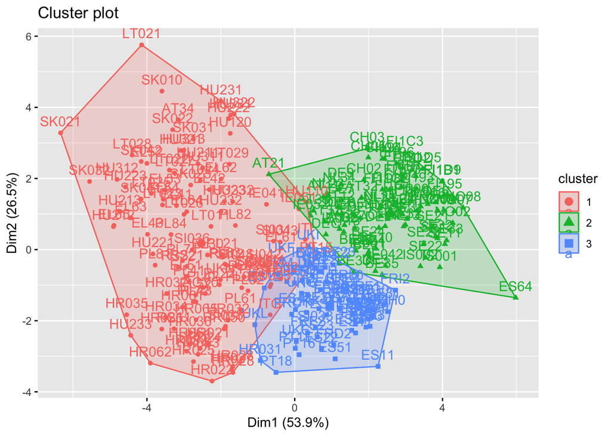

```r
# Fitting & plotting (on 2-dim)
hc_res3 <- hcut(d_in, k = 3, hc_method = "ward.D2")
fviz_cluster(hc_res3, d_in, ellipse.type = "convex")
```

**Interpretation**: we observe the same ouliers in the K-means plot (ES64, SK021, LT021). Removing them would likely improve the fit of both cluster algorithms.

```r
# Attaching hierarchical labels to the table (alongside k-means labels)
cl_map <- tibble(region  = names(cl_hier3), cl_hier = as.integer(cl_hier3))
df_regions_cl <- df_regions_cl %>%
  left_join(cl_map, by = "region")
df_regions_cl %>%
  kable("html", caption = "Table with hierarchical labels") %>%
  kable_styling(bootstrap_options = "striped", full_width = F) %>%
  scroll_box(height = "400px")
```

Table with hierarchical labels

| regunit | region | n_resp | eqmgmbg | eqpaybg | eqpolbg | eqwrkbg | freehms | hmsacld | hmsfmlsh | trstlgl | trstplc | trstplt | trstprl | trstprt | cl_kmeans | cl_hier |
| --- | --- | --- | --- | --- | --- | --- | --- | --- | --- | --- | --- | --- | --- | --- | --- | --- |
| 1 | CY0 | 685 | 0.0595749 | -0.1371365 | 0.0760244 | 0.1587530 | -1.0355427 | -1.2313997 | -1.1331763 | -0.8405360 | -1.5598072 | -0.8710401 | -0.4783890 | -1.0456977 | 2 | 1 |
| 1 | DE1 | 332 | 0.1232249 | 0.2347126 | 0.2471336 | -0.4795506 | 0.6460318 | 0.8220461 | 0.7421474 | 0.9489978 | 0.7333078 | 0.5461566 | 0.6901506 | 0.5252652 | 1 | 2 |
| 1 | DE2 | 396 | -0.3344906 | 0.2073252 | -0.3382253 | -0.6839773 | 0.6957557 | 0.7153985 | 0.7063181 | 0.8861118 | 0.8020785 | 0.2140171 | 0.4445894 | 0.2221563 | 1 | 2 |
| 1 | DE3 | 82 | 0.7854054 | 0.4398215 | 0.6245855 | 0.8489101 | 0.8886434 | 1.1678188 | 1.0364450 | 0.5595532 | -0.5823272 | 0.3452587 | 0.7706280 | 0.5187603 | 1 | 2 |
| 1 | DE4 | 72 | 0.2412379 | 0.2509730 | -0.0751523 | 0.2406616 | 0.4777226 | 0.9318405 | 0.7099127 | 0.2783732 | 0.2462733 | -0.4567573 | 0.0160150 | -0.2331789 | 1 | 3 |
| 1 | DE6 | 39 | 0.3651047 | 0.7049611 | 0.8193418 | 0.2636886 | 1.2111624 | 1.2099429 | 1.0932333 | 1.3922233 | 1.1659287 | 1.5772412 | 1.7321919 | 1.5079978 | 1 | 2 |
| 1 | DE7 | 181 | -0.4103587 | 0.0180220 | -0.2977188 | -0.7818666 | 0.6701435 | 0.8048748 | 0.6167897 | 0.9770931 | 0.7478806 | 0.4439305 | 0.6430365 | 0.4960136 | 1 | 2 |
| 1 | DE8 | 34 | 0.5815749 | 0.7446513 | 0.0247614 | 0.5752297 | 0.8480029 | 1.2970929 | 0.9538440 | 0.1479560 | -0.0496555 | -0.5292740 | -0.1383816 | -0.0086179 | 1 | 3 |
| 1 | DE9 | 199 | -0.3204833 | -0.2750106 | -0.4489897 | -0.8764377 | 0.5561957 | 0.6840246 | 0.4350061 | 0.9889013 | 0.8507490 | 0.7897508 | 0.9239028 | 0.5777644 | 1 | 2 |
| 1 | DEA | 615 | 0.1827408 | 0.1676517 | 0.1912308 | -0.2750811 | 0.7021028 | 0.8373622 | 0.7074074 | 0.8066286 | 0.7033723 | 0.4118191 | 0.5207729 | 0.3391672 | 1 | 2 |
| 1 | DEB | 103 | -0.1218540 | -0.1674231 | -0.3433980 | -0.7832068 | 0.9950259 | 0.9995504 | 0.8978150 | 0.5816823 | 0.3692417 | 0.3684539 | 0.4707968 | 0.5303285 | 1 | 2 |
| 1 | DEC | 26 | -0.1390041 | 0.5550200 | -0.7244143 | -0.3987791 | 0.5916550 | 0.9908530 | 0.5428243 | 0.8520264 | 0.3600920 | -0.1645272 | 0.0496655 | 0.0604778 | 1 | 2 |
| 1 | DED | 119 | 0.1799593 | 0.1728695 | 0.0865792 | 0.2255750 | 0.2901676 | 0.5259703 | 0.2745782 | 0.2158220 | -0.0630842 | -0.2187156 | -0.1322755 | -0.1295673 | 1 | 3 |
| 1 | DEE | 63 | -0.1464418 | -0.2188691 | -0.2546443 | 0.5948380 | 0.3058068 | 0.6840246 | 0.5578014 | -0.2878972 | -0.3624944 | -0.5106692 | -0.6895606 | -0.5055936 | 2 | 3 |
| 1 | DEF | 100 | 0.2693240 | 0.5130366 | 0.3523556 | 0.1181582 | 0.8313403 | 0.7210812 | 0.8070206 | 1.2377694 | 1.3139841 | 0.4227971 | 0.8865099 | 0.2704509 | 1 | 2 |
| 1 | DEG | 59 | 0.1148507 | 0.6299906 | -0.0963532 | 0.9544971 | 0.5232232 | 0.8098219 | 0.6090389 | 0.0108562 | 0.1707604 | -0.3951614 | -0.5119502 | -0.3529210 | 1 | 3 |
| 1 | ITC | 883 | 0.6935714 | 0.2930999 | 0.7023768 | 1.2197591 | 0.0475818 | -0.2824515 | -0.2088679 | -0.0622318 | -0.2108668 | -0.2101652 | -0.0647698 | -0.2774461 | 2 | 3 |
| 1 | ITF | 618 | 0.0916122 | -0.0478570 | 0.0835568 | 0.9141017 | -0.2143784 | -0.6251887 | -0.0764871 | -0.3249402 | -0.1382878 | -0.5125372 | -0.4853891 | -0.4884463 | 2 | 1 |
| 1 | ITG | 332 | 0.5332560 | 0.0566866 | 0.5265832 | 1.0798241 | -0.0912590 | -0.5492087 | -0.0965805 | -0.3163351 | -0.1515865 | -0.9184112 | -0.9645841 | -1.0008931 | 2 | 1 |
| 1 | ITH | 495 | 0.7241754 | 0.3590390 | 0.7462597 | 1.0415312 | 0.2504352 | -0.3943217 | 0.2004361 | 0.2441626 | 0.1906964 | -0.0891922 | 0.2204005 | -0.1431505 | 1 | 3 |
| 1 | ITI | 537 | 0.1419792 | -0.2566908 | 0.1968030 | 0.5862387 | -0.4008995 | -0.2716074 | -0.2326626 | 0.4345490 | 0.4630286 | 0.1444075 | 0.3826219 | 0.1604917 | 1 | 1 |
| 1 | UKC | 75 | 0.6570677 | 0.6826725 | 0.0524299 | 0.2892741 | 0.9605881 | 1.2985038 | 1.2158958 | -0.7777690 | -0.9090325 | -1.1501359 | -1.6037578 | -1.0738084 | 2 | 3 |
| 1 | UKD | 172 | 0.2276205 | 0.5191060 | -0.0996605 | -0.4813675 | 0.6261634 | 0.9000019 | 0.7372928 | 0.2604838 | -0.8204628 | -0.6310724 | -0.5871061 | -0.5031058 | 2 | 3 |
| 1 | UKE | 133 | 0.0399545 | 0.2370000 | -0.1872068 | -0.1545106 | 0.5702927 | 0.8507792 | 0.7604278 | -0.1637953 | -0.5741948 | -0.6032933 | -0.6952699 | -0.5368467 | 2 | 3 |
| 1 | UKF | 157 | -0.3554947 | -0.1614767 | -0.3103339 | -0.5081006 | 0.4634811 | 0.7668570 | 0.4667309 | 0.1660982 | -0.6380314 | -0.5161322 | -0.6567635 | -0.4206651 | 2 | 3 |
| 1 | UKG | 149 | 0.1998480 | 0.5603751 | 0.3159602 | -0.3853172 | 0.7691932 | 0.9324073 | 0.5890459 | -0.1604710 | -0.7063740 | -0.6142202 | -0.9389965 | -0.4313770 | 2 | 3 |
| 1 | UKH | 153 | 0.5714848 | 0.3137242 | 0.0225331 | -0.4688174 | 0.7554328 | 0.6265992 | 0.7825683 | 0.3101974 | -0.4631769 | -0.4812541 | -0.4271603 | -0.3766258 | 1 | 3 |
| 1 | UKI | 172 | 0.2824308 | -0.0006437 | -0.1485001 | 0.1132847 | 0.3417970 | 0.3410168 | -0.1366898 | 0.5957903 | -0.8204628 | 0.0967380 | 0.2463916 | 0.3064439 | 1 | 3 |
| 1 | UKJ | 217 | 0.3820676 | 0.4001281 | -0.0460059 | -0.3684238 | 0.6860053 | 0.5289584 | 0.7875322 | 0.2624363 | -0.3048424 | -0.3803445 | -0.3433980 | -0.1434436 | 1 | 3 |
| 1 | UKK | 158 | 0.7375482 | 0.6050004 | 0.5909289 | -0.3119852 | 0.7625536 | 0.7980632 | 0.8573437 | 0.0025626 | -0.5481816 | -0.9877420 | -1.1294313 | -0.7616913 | 2 | 3 |

[output cut: 234 more lines]

```r
# Cluster profiles for Ward
profile_hier <- df_regions_cl %>%
  group_by(cl_hier) %>%
  summarise(across(all_of(features), mean), .groups = "drop")
profile_hier %>%
  kable("html", caption = "Cluster profiles for Wards") %>%
  kable_styling(bootstrap_options = "striped", full_width = F) %>%
  scroll_box(width = "100%", height = "auto")
```

Cluster profiles for Wards

| cl_hier | freehms | hmsacld | hmsfmlsh | eqmgmbg | eqpolbg | eqwrkbg | eqpaybg | trstprl | trstlgl | trstplc | trstplt | trstprt |
| --- | --- | --- | --- | --- | --- | --- | --- | --- | --- | --- | --- | --- |
| 1 | -0.9804953 | -1.0361077 | -0.9811411 | -0.7061723 | -0.6943805 | -0.4476267 | -0.7144609 | -0.6297056 | -0.6594591 | -0.6304387 | -0.5709824 | -0.5373964 |
| 2 | 0.7396077 | 0.7699510 | 0.7297537 | 0.3807804 | 0.4721810 | -0.0119088 | 0.4839370 | 1.1165038 | 1.0467635 | 0.9149395 | 1.0598803 | 1.0913826 |
| 3 | 0.7007285 | 0.7551974 | 0.7143095 | 0.6973875 | 0.5617199 | 0.7633797 | 0.5803729 | -0.3638178 | -0.2256041 | -0.1068765 | -0.3901461 | -0.4862555 |

**Interpretation**:

In the **first cluster (112 regions, red on the plot)**, we can see that:

- ‘freehms’, ‘hmsacld’, ‘hmsfmlsh’ (LGBT tolerance variables) are ≈0,98 to ≈1,04 below average — drastically lower;
- ‘eqmgmbg’, ‘eqpolbg’, ‘eqwrkbg’, ‘eqpaybg’ (gender equality support variables) are ≈0,45 to ≈0,71 below average — moderately to drastically lower;
- ‘trstprl’, ‘trstlgl’, ‘trstplc’, ‘trstplt’, ‘trstprt’ (institutional trust variables) are ≈0,54 to ≈0,66 below average — moderately lower.

Conclusion: we can label this cluster as **“Very low tolerance, against equality, low trust”**.

In the **second cluster (85 regions, green on the plot)**, we can see that:

- ‘freehms’, ‘hmsacld’, ‘hmsfmlsh’ (LGBT tolerance variables) are ≈0,74 to ≈0,77 above average — considerably higher;
- ‘eqmgmbg’, ‘eqpolbg’, ‘eqwrkbg’, ‘eqpaybg’ (gender equality support variables) are ≈0,38 to ≈0,48 above average (with eqwrkbg ≈-0,01 — about average) — moderately higher overall;
- ‘trstprl’, ‘trstlgl’, ‘trstplc’, ‘trstplt’, ‘trstprt’ (institutional trust variables) are ≈0,91 to ≈1,12 above average — very high.

Conclusion: we can label this cluster as **“High tolerance, pro-equality (work parity ~ average), very high trust”**.

In the **third cluster (67 regions, blue on the plot)**, we can see that:

- ‘freehms’, ‘hmsacld’, ‘hmsfmlsh’ (LGBT tolerance variables) are ≈0,70 to ≈0,76 above average — considerably higher;
- ‘eqmgmbg’, ‘eqpolbg’, ‘eqwrkbg’, ‘eqpaybg’ (gender equality support variables) are ≈0,56 to ≈0,76 above average — high;
- ‘trstprl’, ‘trstlgl’, ‘trstplc’, ‘trstplt’, ‘trstprt’ (institutional trust variables) are ≈0,11 to ≈0,49 below average — moderately lower.

Conclusion: we can label this cluster as **“High tolerance, pro-equality, low trust”**.

As we can see, the clusters are a bit different from the K-means result, which makes sense as we used completely different approaches to clustering.

```r
df_solitude <- unzip("solitude.zip") |>
  read_delim(col_names=TRUE,
             delim=",",
             progress=FALSE,
             show_col_types = FALSE,
             locale = readr::locale(encoding = "latin1"))
```

## Supervised Machine Learning

### Data Wrangle

1. **Describe the step and decisions you took when wrangling data. When there is discussion in your group about the right decision, briefly describe the different (opposing) opinions. Code this steps in the ‘wrangle’-chunck.**

Answer:

First, we will examine the composition of the df, then, since machine learning does not work with NA values, we will check whether our df contains any. This information will help us in the following steps to decide whether or not we need to impute the missing values.

```r
kable(head(df_solitude), caption = "Orginal DataFrame")
```

Orginal DataFrame

| lonely_obs | male | agea | mnactic | domicil | hhmmb | eduyrs | trust_other | health | netustm | aesfdrk | hlthhmp | hincfel |
| --- | --- | --- | --- | --- | --- | --- | --- | --- | --- | --- | --- | --- |
| 0 | 1 | 65 | Retired | town | 2 | 12 | 1.5 | 3 | 180 | 2 | 0 | 1 |
| 1 | 0 | 21 | Education | bigcity | 1 | 14 | 1.1 | 2 | 570 | 3 | 1 | 2 |
| 0 | 0 | 53 | PaidWork | town | 3 | 16 | 2.3 | 1 | 30 | 3 | 0 | 1 |
| 1 | 0 | 78 | Retired | bigcity | 1 | 14 | 1.8 | 3 | 0 | 3 | 0 | 2 |
| 0 | 1 | 64 | Retired | village | 2 | 12 | 1.7 | 2 | 120 | 1 | 0 | 2 |
| 0 | 0 | 59 | PaidWork | village | 2 | 16 | 2.0 | 1 | 120 | 2 | 0 | 1 |

```r
sapply(df_solitude, function(x)sum(is.na(x)))
```

```
##  lonely_obs        male        agea     mnactic     domicil       hhmmb
##           0           0           0           0           0           0
##      eduyrs trust_other      health     netustm     aesfdrk     hlthhmp
##           0           0           0           0           0           0
##     hincfel
##           0
```

The tables above show us:

1. Some of the features are categorical - which tells us that we shall employ one-hot encoding for those variables (ML algorithms only accept numerical variables and work better with those)

2. While the male variable is already in dumy format, it’s better to turn it into a categorical variable - gender and then after apply a one-hot encoding. This will allow us firstly to better capture the influence of male and female, and to avoid if we ever apply standarization that the variable male - which is numeric, also be standardize. The standarization of this variable will make it loose its meaning.

3. The label - lonely_obs is numeric. Caret only accept factor variables for the label, so we shall mutate this variable here. Also since mutating a variable does not require information about the all dataset, we are safe here regarding any data leakage.

4. The Dataset contains no NAs so we shall not care about imputation in later stages.

Therefore for the next - data wrangle step, will consist of mutate the outcome variable into factor and create a new variable - gender based on the ismale variable.

```r
df_solitude[, "lonely_obs"] <- factor(if_else(df_solitude[, "lonely_obs"] == 1, "yes", "no"), levels = c("yes", "no")) #Turn labels into factor for caret

df_solitude <- df_solitude %>% mutate(sex = (ifelse(male == 1, "male", "female")))
df_solitude[, "male"] <- NULL
kable(head(df_solitude), caption = "Table after transformation")
```

Table after transformation

| lonely_obs | agea | mnactic | domicil | hhmmb | eduyrs | trust_other | health | netustm | aesfdrk | hlthhmp | hincfel | sex |
| --- | --- | --- | --- | --- | --- | --- | --- | --- | --- | --- | --- | --- |
| no | 65 | Retired | town | 2 | 12 | 1.5 | 3 | 180 | 2 | 0 | 1 | male |
| yes | 21 | Education | bigcity | 1 | 14 | 1.1 | 2 | 570 | 3 | 1 | 2 | female |
| no | 53 | PaidWork | town | 3 | 16 | 2.3 | 1 | 30 | 3 | 0 | 1 | female |
| yes | 78 | Retired | bigcity | 1 | 14 | 1.8 | 3 | 0 | 3 | 0 | 2 | female |
| no | 64 | Retired | village | 2 | 12 | 1.7 | 2 | 120 | 1 | 0 | 2 | male |
| no | 59 | PaidWork | village | 2 | 16 | 2.0 | 1 | 120 | 2 | 0 | 1 | female |

Above is the a glimpse of the newer dataframe after data wrangling.

#### Distribution of the labels

Since the outcome is a nominal variable, we will use classification models to predict whether a respondent feels lonely or not. In this regard, it is important to note that classification models are sensitive to label distribution. If there is an imbalance in the distribution of categories in the label variable, the model will tend to successfully predict the category with the highest number of occurrences and fail to predict the one with the fewest occurrences.

So that is why it is important to have a look on the outcome variable distribution.

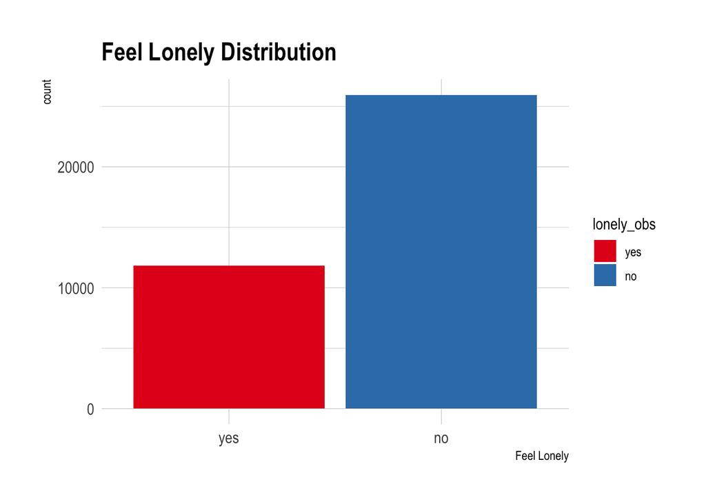

```r
#library(scales)
library(viridis)
#remotes::install_git("https://codeberg.org/hrbrmstr/hrbrthemes.git")
library(hrbrthemes)
#table(df_solitude$lonely_obs)

ggplot(df_solitude, aes(lonely_obs, fill =lonely_obs)) + geom_bar() + labs(title = "Feel Lonely Distribution") + xlab("Feel Lonely") + scale_fill_brewer(palette = "Set1") + theme_ipsum()
```

We observe an imbalance in the data that could affect the quality of our model. Approximately 69% of respondents said they did not feel lonely, while only 31% said they did feel lonely. This imbalance could affect the quality of our prediction model.

```r
library(htmltools)


table1::table1(~. |lonely_obs , data=df_solitude) %>%
  kable("html", caption = "Loneliness Distribution by Predictors") %>%
  kable_styling(bootstrap_options = "striped", full_width = F) %>%
  scroll_box(width = "100%", height = "auto")
```

Loneliness Distribution by Predictors

|  | yes | no | Overall |
| --- | --- | --- | --- |
|  | (N=11815) | (N=25960) | (N=37775) |
| agea |  |  |  |
| Mean (SD) | 53.1 (19.6) | 51.0 (18.1) | 51.7 (18.6) |
| Median [Min, Max] | 55.0 [15.0, 90.0] | 52.0 [15.0, 90.0] | 53.0 [15.0, 90.0] |
| mnactic |  |  |  |
| Education | 771 (6.5%) | 1664 (6.4%) | 2435 (6.4%) |
| Housework | 794 (6.7%) | 1546 (6.0%) | 2340 (6.2%) |
| Other | 159 (1.3%) | 290 (1.1%) | 449 (1.2%) |
| PaidWork | 5318 (45.0%) | 14611 (56.3%) | 19929 (52.8%) |
| Retired | 3631 (30.7%) | 6726 (25.9%) | 10357 (27.4%) |
| sickDisabled | 433 (3.7%) | 368 (1.4%) | 801 (2.1%) |
| Unemployed | 709 (6.0%) | 755 (2.9%) | 1464 (3.9%) |
| domicil |  |  |  |
| bigcity | 2646 (22.4%) | 4720 (18.2%) | 7366 (19.5%) |
| countryside | 473 (4.0%) | 1463 (5.6%) | 1936 (5.1%) |
| suburb | 1296 (11.0%) | 2980 (11.5%) | 4276 (11.3%) |
| town | 3367 (28.5%) | 7535 (29.0%) | 10902 (28.9%) |
| village | 4033 (34.1%) | 9262 (35.7%) | 13295 (35.2%) |
| hhmmb |  |  |  |
| Mean (SD) | 2.19 (1.28) | 2.69 (1.30) | 2.53 (1.31) |
| Median [Min, Max] | 2.00 [1.00, 10.0] | 2.00 [1.00, 12.0] | 2.00 [1.00, 12.0] |
| eduyrs |  |  |  |
| Mean (SD) | 12.6 (4.30) | 13.7 (4.01) | 13.3 (4.13) |
| Median [Min, Max] | 12.0 [0, 69.0] | 13.0 [0, 50.0] | 13.0 [0, 69.0] |
| trust_other |  |  |  |
| Mean (SD) | 1.47 (0.593) | 1.67 (0.566) | 1.61 (0.582) |
| Median [Min, Max] | 1.50 [0, 3.00] | 1.70 [0, 3.00] | 1.70 [0, 3.00] |
| health |  |  |  |
| Mean (SD) | 2.41 (0.957) | 2.02 (0.851) | 2.14 (0.903) |
| Median [Min, Max] | 2.00 [1.00, 5.00] | 2.00 [1.00, 5.00] | 2.00 [1.00, 5.00] |
| netustm |  |  |  |
| Mean (SD) | 172 (195) | 196 (192) | 188 (193) |
| Median [Min, Max] | 120 [0, 1440] | 120 [0, 1440] | 120 [0, 1440] |
| aesfdrk |  |  |  |
| Mean (SD) | 2.04 (0.795) | 1.80 (0.736) | 1.88 (0.763) |
| Median [Min, Max] | 2.00 [1.00, 4.00] | 2.00 [1.00, 4.00] | 2.00 [1.00, 4.00] |
| hlthhmp |  |  |  |
| Mean (SD) | 0.354 (0.478) | 0.216 (0.411) | 0.259 (0.438) |
| Median [Min, Max] | 0 [0, 1.00] | 0 [0, 1.00] | 0 [0, 1.00] |
| hincfel |  |  |  |
| Mean (SD) | 2.12 (0.857) | 1.73 (0.727) | 1.85 (0.792) |
| Median [Min, Max] | 2.00 [1.00, 4.00] | 2.00 [1.00, 4.00] | 2.00 [1.00, 4.00] |
| sex |  |  |  |
| female | 6992 (59.2%) | 13023 (50.2%) | 20015 (53.0%) |
| male | 4823 (40.8%) | 12937 (49.8%) | 17760 (47.0%) |

### Data Split

2. **Split, train and assess the supervised machine learning algorithms seen in class and select the best solution. Describe the different steps and decisions you took. When there is discussion in your group about the right decision, briefly describe the different (opposing) opinions. Code this steps in the ‘ML’-chunck.**

Answer:

As we have a total of 37,775 data points, we decide to train our model on 80% of the dataset and test its quality on the remaining 20%.

```r
set.seed(42) #Thinking about changing seed

#To avoid Data Leakages we shall do the pre-processing after splitting

split_1 = initial_split(df_solitude, prop = .8, strata = lonely_obs)
train_val_pool <- training(split_1)
test_set       <- testing(split_1)  #We don't touch to avoid data leakages

split_2 <- initial_split(train_val_pool, prop = 0.75, strata = lonely_obs)

train_set      <- training(split_2)
validation_set <- testing(split_2)

X_train = dplyr::select(train_set, !lonely_obs)
y_train = train_set$lonely_obs

X_valid = dplyr::select(validation_set, !lonely_obs)
y_valid = validation_set$lonely_obs
```

| SET | Observations | Features |
| --- | --- | --- |
| Training | 22665 | 13 |
| Validation | 7555 | 13 |
| Test | 7555 | 13 |

We have 22665 data points in the Training dataset, and 7555 both in the Validation and Test dataset. All three sets have 13 columns (1 label, and 12 features).

#### Feature engineering

As mentioned above, certain categorical variables must be converted into numerical variables for machine learning algorithms to work better. In addition, we decided to scale and centre our data so that we could compare the effect of each variable. We will do the same preprocess for the train and test dataset.

```r
library(kableExtra)
#Make dummies
#install.packages("fastDummies")

pp_model <- preProcess(X_train, method = c("center", "scale"))
X_train_scaled <- predict(pp_model, newdata = X_train)
X_valid_scaled <- predict(pp_model, newdata = X_valid)

X_train_scaled1 <- fastDummies::dummy_columns(X_train_scaled, remove_selected_columns = TRUE)
X_valid_scaled1 <- fastDummies::dummy_columns(X_valid_scaled, remove_selected_columns = TRUE)

head(X_train_scaled1) %>%
  kable("html", caption = "Train Set After Scaling") %>%
  kable_styling(bootstrap_options = "striped", full_width = F) %>%
  scroll_box(width = "100%", height = "auto")
```

Train Set After Scaling

| agea | hhmmb | eduyrs | trust_other | health | netustm | aesfdrk | hlthhmp | hincfel | mnactic_Education | mnactic_Housework | mnactic_Other | mnactic_PaidWork | mnactic_Retired | mnactic_sickDisabled | mnactic_Unemployed | domicil_bigcity | domicil_countryside | domicil_suburb | domicil_town | domicil_village | sex_female | sex_male |
| --- | --- | --- | --- | --- | --- | --- | --- | --- | --- | --- | --- | --- | --- | --- | --- | --- | --- | --- | --- | --- | --- | --- |
| 0.0730272 | 0.3553019 | 0.6391701 | 1.1901927 | -1.2583313 | -0.8236492 | 1.4741261 | -0.5920631 | -1.0694949 | 0 | 0 | 0 | 1 | 0 | 0 | 0 | 0 | 0 | 0 | 1 | 0 | 1 | 0 |
| 0.0194326 | 0.3553019 | -0.3275343 | 1.0181735 | -0.1568297 | -0.0413475 | 0.1572781 | -0.5920631 | 0.1907132 | 0 | 0 | 0 | 1 | 0 | 0 | 0 | 0 | 0 | 0 | 0 | 1 | 1 | 0 |
| 1.2521081 | -0.4076462 | -1.0525626 | -1.0460578 | -0.1568297 | -0.9801095 | 0.1572781 | 1.6889347 | 0.1907132 | 0 | 0 | 0 | 0 | 1 | 0 | 0 | 0 | 0 | 0 | 0 | 1 | 1 | 0 |
| 0.8233514 | -1.1705942 | -0.5692104 | 0.6741349 | -1.2583313 | -0.0413475 | 0.1572781 | -0.5920631 | -1.0694949 | 0 | 0 | 0 | 0 | 1 | 0 | 0 | 1 | 0 | 0 | 0 | 0 | 1 | 0 |
| -0.5701078 | 1.1182499 | -0.0858582 | 1.3622120 | -1.2583313 | 0.8974146 | -1.1595700 | -0.5920631 | -1.0694949 | 0 | 0 | 0 | 1 | 0 | 0 | 0 | 0 | 0 | 0 | 0 | 1 | 0 | 1 |
| 1.6272702 | -0.4076462 | -0.3275343 | -0.3579807 | -0.1568297 | -0.9801095 | -1.1595700 | -0.5920631 | -1.0694949 | 0 | 1 | 0 | 0 | 0 | 0 | 0 | 0 | 0 | 0 | 1 | 0 | 1 | 0 |

```r
head(X_valid_scaled1) %>%
  kable("html", caption = "Validation Set After Scaling") %>%
  kable_styling(bootstrap_options = "striped", full_width = F) %>%
  scroll_box(width = "100%", height = "auto")
```

Validation Set After Scaling

| agea | hhmmb | eduyrs | trust_other | health | netustm | aesfdrk | hlthhmp | hincfel | mnactic_Education | mnactic_Housework | mnactic_Other | mnactic_PaidWork | mnactic_Retired | mnactic_sickDisabled | mnactic_Unemployed | domicil_bigcity | domicil_countryside | domicil_suburb | domicil_town | domicil_village | sex_female | sex_male |
| --- | --- | --- | --- | --- | --- | --- | --- | --- | --- | --- | --- | --- | --- | --- | --- | --- | --- | --- | --- | --- | --- | --- |
| 0.7161622 | -0.4076462 | -0.3275343 | -0.1859614 | 0.9446719 | -0.0413475 | 0.1572781 | -0.5920631 | -1.0694949 | 0 | 0 | 0 | 0 | 1 | 0 | 0 | 0 | 0 | 0 | 1 | 0 | 0 | 1 |
| 0.3945947 | -0.4076462 | 0.6391701 | 0.6741349 | -1.2583313 | -0.3542681 | 0.1572781 | -0.5920631 | -1.0694949 | 0 | 0 | 0 | 1 | 0 | 0 | 0 | 0 | 0 | 0 | 0 | 1 | 1 | 0 |
| -0.2485403 | 1.1182499 | 0.1558179 | -0.3579807 | -1.2583313 | -0.1978078 | 0.1572781 | -0.5920631 | -1.0694949 | 0 | 0 | 0 | 1 | 0 | 0 | 0 | 0 | 0 | 0 | 0 | 1 | 0 | 1 |
| 1.5736756 | -0.4076462 | -1.0525626 | 0.3300964 | -1.2583313 | -0.9801095 | -1.1595700 | -0.5920631 | 0.1907132 | 0 | 1 | 0 | 0 | 0 | 0 | 0 | 0 | 0 | 0 | 0 | 1 | 1 | 0 |
| -0.5165132 | -0.4076462 | -0.5692104 | 0.8461542 | -0.1568297 | -0.0413475 | 0.1572781 | -0.5920631 | -1.0694949 | 0 | 0 | 0 | 1 | 0 | 0 | 0 | 1 | 0 | 0 | 0 | 0 | 1 | 0 |
| 1.3592972 | -0.4076462 | -1.2942387 | 0.6741349 | 0.9446719 | -0.9801095 | -1.1595700 | -0.5920631 | -1.0694949 | 0 | 0 | 0 | 0 | 1 | 0 | 0 | 0 | 0 | 0 | 1 | 0 | 0 | 1 |

### Model Train

To predict whether a respondent feels lonely based on the various predictors available to us, we use three classification models: glm, naive bayes, and random forest. We ran all models with five-fold cross-validation. The best model is chosen based on average accuracy and a more in-depth analysis of each model. Since our labels are imbalanced, accuracy alone cannot be a good indicator of the best model.

For the naive bayes model, we tuned the model using three parameters: laplace, usekernel, and adjust. This allows us to obtain the best model.

We wanted to run several random forest models by adjusting the number of three, but due to the time required to do so, we decided to run the model with the default number of trees and save it in order to load and use it in this analysis.

```r
ctrl <- trainControl(method = "cv", number = 5) #Cross validation for all models

#GLM
myclassifier_logistic = train(x = X_train_scaled1, y = y_train, method = 'glm', family = 'binomial', trControl = ctrl)

#NB
grid_nb <- expand.grid(laplace   = c(0, 1), usekernel = c(TRUE, FALSE), adjust = c(0.5, 1)) ## grid for NB
myclassifier_nb <-  train(x = X_train_scaled1, y = y_train, method = "naive_bayes", tuneGrid = grid_nb, trControl = ctrl)

#rf

#myclassifier_rf <- train(x = X_train_scaled1, y = y_train, method = "rf", trControl = ctrl)

#saveRDS(myclassifier_rf, file = "myclassifier_rf.rds")
myclassifier_rf <- readRDS('/Users/janebossbaby/Downloads/data analysis 2025/myclassifier_rf.rds')
```

Multiple random forest. Can’t work! not enough time!

```r
#rf

# trees <- seq(100, 500, by = 100)
# rf_results <- list()
#
# for (nt in trees) {
#   fit <- train(x = X_train_scaled1, y = y_train, method = "rf", trControl = ctrl, ntree = nt)
#   # store best model for that ntree
#   rf_results[[paste0("ntree_", nt)]] <- fit
# }
#
# sapply(rf_results, function(m) max(m$results$Accuracy))
```

#### Model evaluation and comparison

```r
results <- resamples(list(NB=myclassifier_nb, GLM=myclassifier_logistic,  RF=myclassifier_rf))

summary(results)
```

```
##
## Call:
## summary.resamples(object = results)
##
## Models: NB, GLM, RF
## Number of resamples: 5
##
## Accuracy
##          Min.   1st Qu.    Median      Mean   3rd Qu.      Max. NA's
## NB  0.6927658 0.6950574 0.6984337 0.6977279 0.7008604 0.7015222    0
## GLM 0.7160821 0.7181297 0.7195499 0.7212884 0.7262299 0.7264505    0
## RF  0.7187914 0.7263901 0.7275535 0.7262743 0.7277741 0.7308626    0
##
## Kappa
##          Min.   1st Qu.    Median      Mean   3rd Qu.      Max. NA's
## NB  0.2288361 0.2355264 0.2408506 0.2427134 0.2515466 0.2568076    0
## GLM 0.2276130 0.2279327 0.2283468 0.2347296 0.2419986 0.2477568    0
## RF  0.1873417 0.2061444 0.2150566 0.2112410 0.2188519 0.2288107    0
```

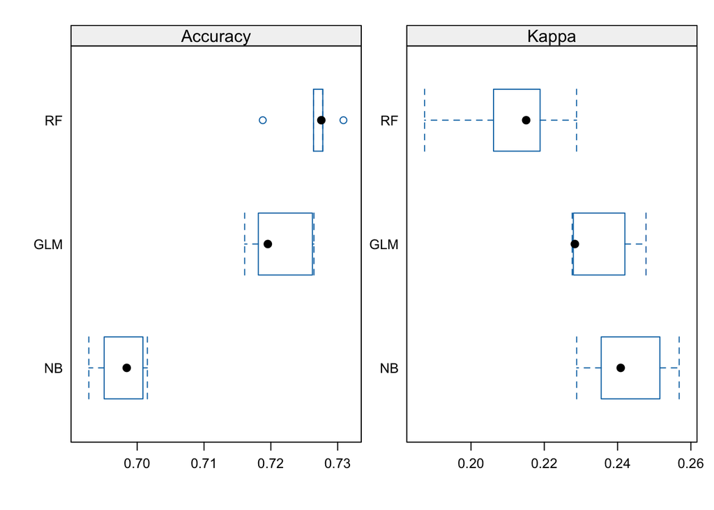

```r
# box and whisker plots to compare models
scales <- list(x=list(relation="free"), y=list(relation="free"))
bwplot(results, scales=scales)
```

When considering Accuracy, the Random Forest model performed best, achieving a mean accuracy of 72%. However, as previously noted, accuracy alone is not an adequate performance indicator in the presence of class imbalance. This limitation is reflected in the model’s Cohen’s Kappa value: the Random Forest reaches only 0.21 on average, indicating that just 21% of its correct classifications exceed what would be expected by chance. In comparison, both the GLM and Naive Bayes models achieve slightly higher Kappa values of approximately 0.24 on average, suggesting that—despite lower accuracy—they provide more meaningful predictive power beyond chance agreement.

Before selecting the final model, it is essential to evaluate performance on the validation data and refine the classification threshold to better capture cases of loneliness. Since the primary objective of this study is to identify individuals experiencing loneliness (the positive class), we prioritise **Recall**. From a prevention and intervention perspective, it is more detrimental to misclassify a lonely individual as not lonely—thereby missing a potentially important intervention—than to incorrectly flag someone as lonely when they are not.

#### Random Forest Evaluation

```r
#RF
y_pred_rf = predict(myclassifier_rf, newdata = X_valid_scaled1)
confusionMatrix(y_pred_rf, y_valid)
```

```
## Confusion Matrix and Statistics
##
##           Reference
## Prediction  yes   no
##        yes  502  224
##        no  1861 4968
##
##                Accuracy : 0.724
##                  95% CI : (0.7138, 0.7341)
##     No Information Rate : 0.6872
##     P-Value [Acc > NIR] : 1.655e-12
##
##                   Kappa : 0.2087
##
##  Mcnemar's Test P-Value : < 2.2e-16
##
##             Sensitivity : 0.21244
##             Specificity : 0.95686
##          Pos Pred Value : 0.69146
##          Neg Pred Value : 0.72749
##              Prevalence : 0.31277
##          Detection Rate : 0.06645
##    Detection Prevalence : 0.09610
##       Balanced Accuracy : 0.58465
##
##        'Positive' Class : yes
##
```

The Random Forest model achieved a statistically significant overall accuracy of 72.4%. However, as previously discussed, our primary focus is on **Recall (Sensitivity)** for the loneliness class. In this regard, the model performs poorly, identifying only 21% of individuals who report feeling lonely. This indicates that the majority of truly lonely individuals are misclassified as not lonely, which substantially limits the model’s usefulness for early detection and preventative intervention.

#### GLM Evaluation

```r
#glm
y_pred_logistic = predict(myclassifier_logistic, newdata = X_valid_scaled1)
confusionMatrix(y_pred_logistic, y_valid)
```

```
## Confusion Matrix and Statistics
##
##           Reference
## Prediction  yes   no
##        yes  656  428
##        no  1707 4764
##
##                Accuracy : 0.7174
##                  95% CI : (0.7071, 0.7275)
##     No Information Rate : 0.6872
##     P-Value [Acc > NIR] : 6.118e-09
##
##                   Kappa : 0.2289
##
##  Mcnemar's Test P-Value : < 2.2e-16
##
##             Sensitivity : 0.27761
##             Specificity : 0.91757
##          Pos Pred Value : 0.60517
##          Neg Pred Value : 0.73621
##              Prevalence : 0.31277
##          Detection Rate : 0.08683
##    Detection Prevalence : 0.14348
##       Balanced Accuracy : 0.59759
##
##        'Positive' Class : yes
##
```

#### Naive Bayes Evaluation

```r
#nb
y_pred_nb = predict(myclassifier_nb, newdata = X_valid_scaled1)
confusionMatrix(y_pred_nb, y_valid)
```

```
## Confusion Matrix and Statistics
##
##           Reference
## Prediction  yes   no
##        yes  917  906
##        no  1446 4286
##
##                Accuracy : 0.6887
##                  95% CI : (0.6781, 0.6991)
##     No Information Rate : 0.6872
##     P-Value [Acc > NIR] : 0.3978
##
##                   Kappa : 0.2277
##
##  Mcnemar's Test P-Value : <2e-16
##
##             Sensitivity : 0.3881
##             Specificity : 0.8255
##          Pos Pred Value : 0.5030
##          Neg Pred Value : 0.7477
##              Prevalence : 0.3128
##          Detection Rate : 0.1214
##    Detection Prevalence : 0.2413
##       Balanced Accuracy : 0.6068
##
##        'Positive' Class : yes
##
```

The Naive Bayes model achieved an overall accuracy of 69%, which is slightly lower than both the Random Forest and the GLM. However, given the class imbalance, **accuracy is not the primary criterion of interest**. The model attains a **Kappa value of 0.22**, similar to the GLM, indicating that it offers the greatest improvement over chance-level classification compare to the Random Forest. Most importantly, Naive Bayes performs comparatively better in identifying individuals experiencing loneliness, with a **Recall of 38.8%**. Although still modest, this represents a substantial improvement relative to the Random Forest (21%) and the GLM (28%). This means that Naive Bayes succeeds in detecting nearly four out of ten lonely individuals. While its specificity (82%) is lower than that of the other models—reflecting a higher rate of false positives—this trade-off is more acceptable in a prevention-oriented context, where failing to identify lonely individuals carries greater risk than incorrectly flagging non-lonely individuals.

We therefore decided to tune the Naive Bayes prediction threshold to see if this would allow us to increase recall without significantly affecting the accuracy of our model.

#### Model Tuning

```r
# p_yes <- predict(myclassifier_nb, X_test_scaled1, type="prob")[,"yes"]
# ypred01 <- factor(ifelse(p_yes>=0.1,"yes","no"), levels=c("yes","no"))

 library(pROC)


p_yes <- predict(myclassifier_nb, newdata = X_valid_scaled1, type = "prob")[, "yes"]

my_roc_curve <- roc(response = y_valid, predictor = p_yes, levels = c("yes","no"))
# my_roc_curve
# plot(my_roc_curve)

optimal_th = my_roc_curve$threshold[which.max(my_roc_curve$sensitivities + my_roc_curve$specificities)]
optimal_th
```

```
## [1] 0.2006151
```

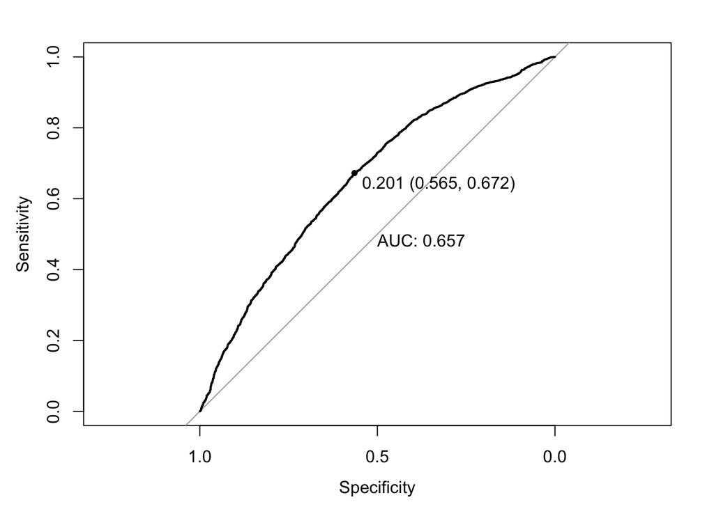

```r
roc_2 = roc(y_valid ~ p_yes, plot=T, print.auc=T,
          print.thres="best", print.thres.patterns="Best threshold: %1.2f")
```

```r
target_coords <- coords(
  my_roc_curve,
  x = "best",
  input = "threshold",
  ret = c("threshold", "sensitivity", "specificity", "ppv") # 'ppv' is Precision
)

target_coords %>%
  kable("html") %>%
  kable_styling(bootstrap_options = "striped", full_width = F)
```

|  | threshold | sensitivity | specificity | ppv |
| --- | --- | --- | --- | --- |
| threshold | 0.2006151 | 0.6723806 | 0.5645366 | 0.7723451 |

```r
pred_optimal = ifelse(p_yes>optimal_th , "no", "yes")
# pred_optimal = ifelse(y_pred4>optimal, "user", "non-user")
confmat_opt = table(y_valid, pred_optimal)

#recall
recall <- diag(confmat_opt)/rowSums(confmat_opt)
recall %>%
  kable("html", col.names = "Recall Score") %>%
  kable_styling(bootstrap_options = "striped", full_width = F)
```

|  | Recall Score |
| --- | --- |
| yes | 0.5645366 |
| no | 0.6723806 |

```r
#precision
precision <- diag(confmat_opt)/colSums(confmat_opt)
precision%>%
  kable("html", col.names = "Precision Score") %>%
  kable_styling(bootstrap_options = "striped", full_width = F)
```

|  | Precision Score |
| --- | --- |
| no | 0.4395387 |
| yes | 0.7723451 |

Using the threshold derived from the ROC curve (~0.2), we are able to identify approximately 56% of people who are truly lonely and correctly identify 67% of people who are not lonely. The model has an accuracy rate of 44% when predicting loneliness (many false positive) and 77% when predicting the absence of loneliness. After adjustment, the model performs significantly better than the previous one.

### Model Selection

Next, we use the best model with the optimal threshold to make a final decision regarding the final model. We used the same pre-processing for the test variables as we did for the training and validation variables.

```r
X_test = dplyr::select(test_set, !lonely_obs)
y_test = test_set$lonely_obs

pp_model <- preProcess(X_train, method = c("center", "scale"))
X_test_scaled <- predict(pp_model, newdata = X_test)
X_test_scaled1 <- fastDummies::dummy_columns(X_test_scaled, remove_selected_columns = TRUE)



p_yes_test <- predict(myclassifier_nb, newdata =X_test_scaled1, type = "prob")[, "yes"]

pred_fac <- factor(ifelse(p_yes_test > 0.2, "yes","no"), levels=c("yes","no"))
confusionMatrix(pred_fac, y_test, positive = "yes")
```

```
## Confusion Matrix and Statistics
##
##           Reference
## Prediction  yes   no
##        yes 1335 1596
##        no  1028 3596
##
##                Accuracy : 0.6527
##                  95% CI : (0.6418, 0.6634)
##     No Information Rate : 0.6872
##     P-Value [Acc > NIR] : 1
##
##                   Kappa : 0.2417
##
##  Mcnemar's Test P-Value : <2e-16
##
##             Sensitivity : 0.5650
##             Specificity : 0.6926
##          Pos Pred Value : 0.4555
##          Neg Pred Value : 0.7777
##              Prevalence : 0.3128
##          Detection Rate : 0.1767
##    Detection Prevalence : 0.3880
##       Balanced Accuracy : 0.6288
##
##        'Positive' Class : yes
##
```

```r
confmat_opt = table(y_test, pred_fac)

#recall
recall <- diag(confmat_opt)/rowSums(confmat_opt)
print(recall)
```

```
##       yes        no
## 0.5649598 0.6926040
```

The model achieves an accuracy of 65% with a recall of 56%. This result closely matches our evaluation model, indicating that there is no overfitting of the model. Therefore, the best model for our study is the naive Bayesian model with a prediction threshold of 20% for people who feel lonely.

3. **Would you advice social organisations to use your model? Why (not)? What could be improved? What would your next steps be?**

**Answer:**

**Advice on Current Use: Not Recommended**

We would **strongly advise against** using this model in its current state as a standalone screening tool. The risks significantly outweigh the benefits.

- **High Risk of False Negatives:** The model’s 56% recall means it **fails to identify 44% of individuals who are genuinely lonely**. In a social support context, this false-negative rate is unacceptably high. It translates to leaving a large portion of the target vulnerable population without the help they need.
- **Inefficient Resource Allocation:** The trade-off for our recall rate was low precision. This means the model produces a high number of **false positives**—flagging individuals as “lonely” when they are not. For a social organisation with limited resources, this would lead to time and money being wasted on unnecessary interventions, diluting the support available for those who truly need it.

The *only* potential application would be as a minor **supportive tool** to complement existing professional knowledge. For example, it could provide one of several data points to help practitioners prioritise outreach, but it should **never** be the deciding factor.

**What Could Be Improved?**

The model’s primary weakness stems from the data it was trained on.

1. **Address the Data Imbalance:** The most critical issue is the **imbalanced dataset**. The model’s poor recall is likely a direct result of having an insufficient number of “lonely” respondents. It learned to be accurate by defaulting to the majority “not lonely” class. The best solution is to **collect more data from lonely individuals** to create a balanced sample.
2. **Explore Algorithmic Techniques:** If collecting new data is not feasible, we could use **algorithmic sampling techniques**. Methods like **SMOTE** (Synthetic Minority Over-sampling Technique) could be used to create synthetic examples of the “lonely” class, providing the model with more balanced data to learn from.
3. **Re-evaluate Predictors:** Even with a balanced sample, our current predictors may not be the best. We must re-evaluate if the selected variables are truly the strongest indicators of loneliness.

**What Would Your Next Steps Be?**

Given the model’s current performance, a pivot in strategy is required. Here are my recommended next steps:

1. **Halt Predictive Deployment:** Immediately **pause any consideration of using this model for prediction**.
2. **Pivot to Explanatory Analysis:** Instead of *predicting*, we should first use the model to *understand*. My next step would be to conduct a **feature importance analysis**. This will reveal which variables in our current data have the **strongest statistical impact on loneliness**.
3. **Deliver Actionable Insights:** We can provide the organisation with these findings *now*. Knowing the top 3-5 factors most associated with loneliness can help them refine their current, human-led outreach and support strategies, even without a predictive model.
4. **Develop a New Data Strategy:** Based on these insights, we can build a much more informed plan to either gather new, balanced data or apply the right algorithmic techniques.
5. **Rebuild and Re-evaluate:** Only after addressing the core data problem would we attempt to build and validate a new predictive model, with a clear focus on achieving a much higher, safer recall rate.